# UL Capstone

Instructions

How do you achieve the following using clustering techniques?

1. What is the unlabeled classes you want to achieve?

Next steps:

1. Find a dataset of interest.
2. Explore the data. You should understand how it was gathered, what's in it, and what the variables look like.
3. Try several different approaches and really work to tune a variety of models before choosing what you consider to be the best performer.

Things to keep in mind: -how do clustering and modeling compare?

-What are the advantages of each?

-Why would you want to use one over the other?

The report should include compelling visualizations and actionable insights, telling the story to your intended audience. Walk through the analysis using clean, reproducible code. Include plenty of notes and comments to guide others through your thinking.

Your end-user and the value your project provides to them.

- Quantifiable results based on the research you’ve conducted.
- The visuals you chose and what they represent for your research.
- Next steps you'd take to expand on your work.
- A specified research question your model addresses.
- How you chose your model specification and what alternatives you compared it to.
- The practical uses of your model for an audience of interest.
- Any weak points or shortcomings of your model.

# Startups: Boom or Bust

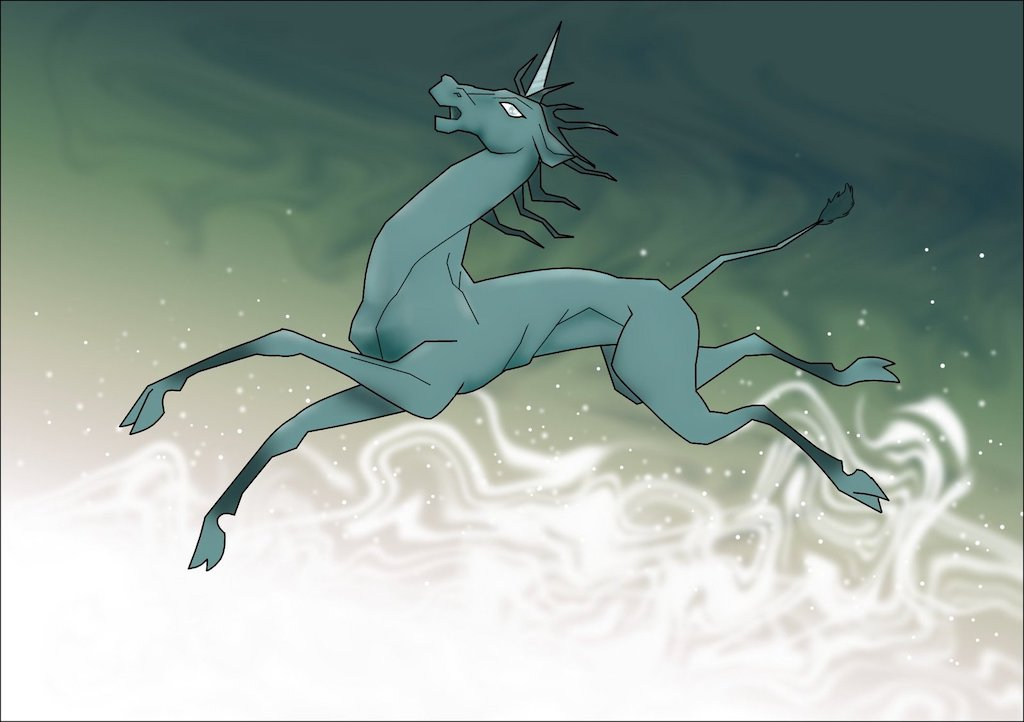

Farooq Hassan Unsupervised Learning Capstone

# Can we find similar attributes in successful Startups that distinctly classify these companies from the rest?

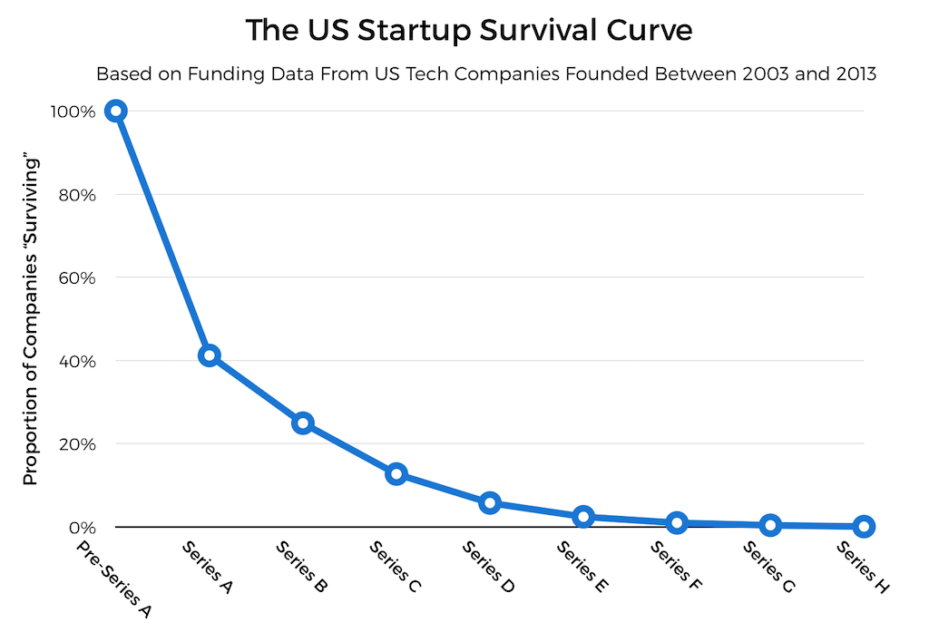

Source: Crunchbase

# What determines Success?

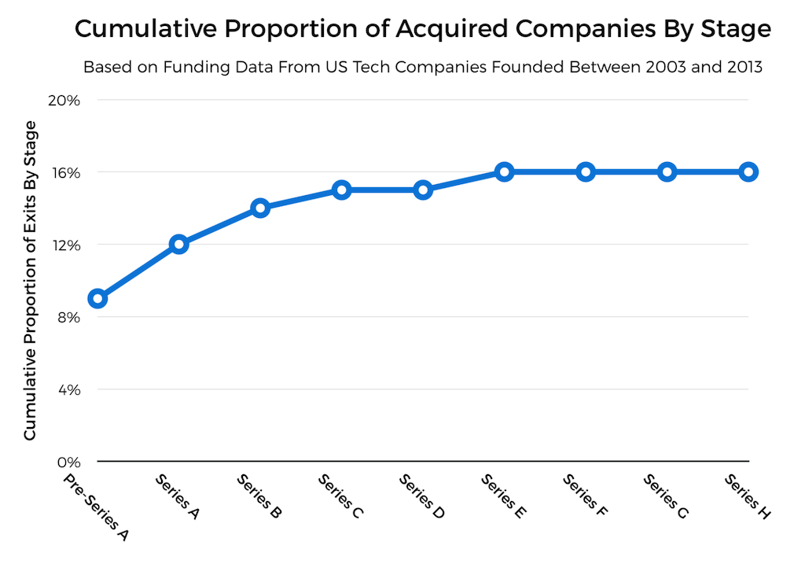

Definition of Success: Total Funding and Valuation

Goal: Identify features of successful companies as determined by our definition

Objective: Use Dimensionality Reduction methods and Clustering Algorithms to view distinct classes

# Data

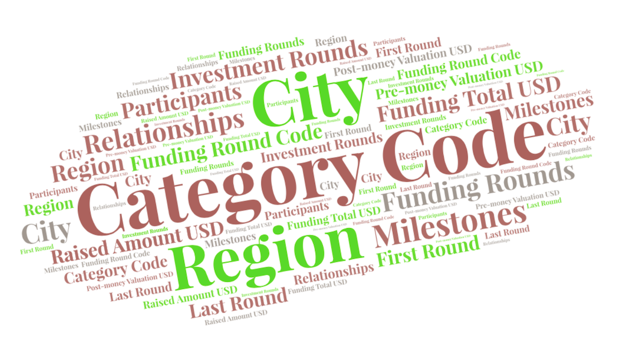

- The dataset contains information about the startup ecosystem: organizations, individuals, company news, funding rounds, acquisitions, and IPOs.
- Source: Crunchbase 2013 Snapshot via Kaggle
- 11 unique tables of which 6 were used for this analysis

# Initialize the environment

```python
pip install prince
```

```python
pip install MulticoreTSNE
```

```python
import numpy as np
import pandas as pd
import scipy
import matplotlib.pyplot as plt
import time
import seaborn as sns
sns.set()
from sklearn.cluster import KMeans
from sklearn.decomposition import PCA
from sklearn.preprocessing import LabelEncoder, StandardScaler, OrdinalEncoder
from sklearn.model_selection import train_test_split
import warnings
warnings.filterwarnings("ignore")
import itertools
from scipy.stats import chi2_contingency
from sklearn.manifold import TSNE
from sklearn.feature_selection import chi2
from MulticoreTSNE import MulticoreTSNE as TSNE
import umap
import time
from sklearn import manifold, metrics
from sklearn.preprocessing import OneHotEncoder
from sklearn.metrics import silhouette_score
from sklearn.cluster import DBSCAN
import prince
from sklearn.cluster import AgglomerativeClustering
from scipy.cluster.hierarchy import dendrogram, linkage
from sklearn.mixture import GaussianMixture
from sklearn.cluster import MeanShift, estimate_bandwidth
import plotly.express as px
import plotly.graph_objects as go
from IPython.display import HTML
import timeit
import time
from datetime import datetime
import random
from collections import Counter
```

# Import Files

```python
from google.colab import files
uploaded = files.upload()
```

```
Saving objects1.csv to objects1.csv
```

```python
# saved cleaned and combined dataframe
df = pd.read_csv('https://raw.githubusercontent.com/qboy21/Thinkful/master/df.csv')
```

```python
# load dataset
d1 = pd.read_csv('objects1.csv')
d2 = pd.read_csv('https://raw.githubusercontent.com/qboy21/Thinkful/master/funding_rounds.csv')
d3 = pd.read_csv('https://raw.githubusercontent.com/qboy21/Thinkful/master/degrees.csv')
d4 = pd.read_csv('https://raw.githubusercontent.com/qboy21/Thinkful/master/offices.csv')
d5 = pd.read_csv('https://raw.githubusercontent.com/qboy21/Thinkful/master/people.csv')
d6 = pd.read_csv('https://raw.githubusercontent.com/qboy21/Thinkful/master/relationships.csv')
```

# Exploratory Data Analysis

```
- Review the Features
- Examine and Clean the Data
- Feature Engineering
```

## Objects (Companies)

```python
# drop object columns that are duplicative with other DFs
d1.drop(['parent_id','normalized_name','country_code','state_code','city','region'], axis=1, inplace=True)
```

```python
d1.info()
```

```
<class 'pandas.core.frame.DataFrame'>
RangeIndex: 462651 entries, 0 to 462650
Data columns (total 20 columns):
id                     462651 non-null object
entity_type            462651 non-null object
entity_id              462651 non-null int64
name                   462649 non-null object
category_code          123186 non-null object
status                 462651 non-null object
founded_at             100441 non-null object
closed_at              2809 non-null object
first_investment_at    16956 non-null object
last_investment_at     16956 non-null object
investment_rounds      462651 non-null int64
invested_companies     462651 non-null int64
first_funding_at       31507 non-null object
last_funding_at        31507 non-null object
funding_rounds         462651 non-null int64
funding_total_usd      462651 non-null int64
first_milestone_at     100358 non-null object
last_milestone_at      100358 non-null object
milestones             462651 non-null int64
relationships          462651 non-null int64
dtypes: int64(7), object(13)
memory usage: 70.6+ MB
```

```python
# Convert date objects to datetime
d1[['founded_at','first_investment_at','last_investment_at','first_funding_at','last_funding_at','first_milestone_at','last_milestone_at']] = d1[['founded_at','first_investment_at','last_investment_at','first_funding_at','last_funding_at','first_milestone_at','last_milestone_at']].apply(pd.to_datetime)
```

```python
# check for duplicates
d1['id'].value_counts()
```

```
f:13253     1
r:18624     1
c:221054    1
c:16970     1
c:218868    1
           ..
c:4561      1
c:235877    1
p:240917    1
p:72558     1
c:50909     1
Name: id, Length: 462651, dtype: int64
```

```python
# explore company status
d1['status'].value_counts()
```

```
operating      443663
acquired         9394
live             4349
closed           2773
ipo              1134
beta              780
development       226
private           219
alpha             113
Name: status, dtype: int64
```

```python
# view a company
d1.loc[d1['id'] == 'c:24869']
```

|  | id | entity_type | entity_id | name | category_code | status | founded_at | closed_at | first_investment_at | last_investment_at | investment_rounds | invested_companies | first_funding_at | last_funding_at | funding_rounds | funding_total_usd | first_milestone_at | last_milestone_at | milestones | relationships |
| --- | --- | --- | --- | --- | --- | --- | --- | --- | --- | --- | --- | --- | --- | --- | --- | --- | --- | --- | --- | --- |
| 103841 | c:24869 | Company | 24869 | Perficient | consulting | ipo | 1998-01-01 | NaN | NaT | NaT | 0 | 0 | 2002-01-07 | 2013-10-23 | 13 | 57923499 | 2010-01-01 | 2012-06-01 | 2 | 21 |

## Funding Rounds

```python
# funding rounds
d2.drop(['source_url','created_at','updated_at','created_by'], axis=1, inplace=True)
```

```python
# drop id column for merge and irrelevance
d2.drop(['id','funding_round_id'], axis=1, inplace=True)
```

```python
d2.info()
```

[output not shown]

```python
# check for duplicates
d2['object_id'].value_counts()
```

```
c:169096    15
c:75429     15
c:27486     14
c:12352     13
c:37366     13
            ..
c:59456      1
c:3231       1
c:236382     1
c:13174      1
c:63840      1
Name: object_id, Length: 31939, dtype: int64
```

```python
# Keep only last funding round where multiple rounds occur
d2.drop_duplicates(subset='object_id',keep='last',inplace=True)
```

```python
# check for duplicates
d2['object_id'].value_counts()
```

```
c:31038     1
c:169138    1
c:25837     1
c:247284    1
c:32413     1
           ..
c:272501    1
c:23347     1
c:1308      1
c:232928    1
c:72781     1
Name: object_id, Length: 31939, dtype: int64
```

## Degrees (Universities)

```python
# degrees
d3.drop(['id','subject','created_at','updated_at'], axis=1, inplace=True)
```

```python
d3.info()
```

```
<class 'pandas.core.frame.DataFrame'>
RangeIndex: 109610 entries, 0 to 109609
Data columns (total 4 columns):
object_id       109610 non-null object
degree_type     98392 non-null object
institution     109555 non-null object
graduated_at    58054 non-null object
dtypes: object(4)
memory usage: 3.3+ MB
```

```python
# check for duplicates
d3['object_id'].value_counts()
```

```
p:183805    10
p:93386      9
p:228604     8
p:206784     8
p:65231      8
            ..
p:82049      1
p:39259      1
p:50751      1
p:229405     1
p:69673      1
Name: object_id, Length: 68451, dtype: int64
```

```python
# determine which degrees to keep as only certain institutions are relevant
d3.loc[d3['object_id'] == 'p:65231']
```

|  | object_id | degree_type | institution | graduated_at |
| --- | --- | --- | --- | --- |
| 59950 | p:65231 | DIGITAL MARKETING | Harvard Business School | 2009-01-01 |
| 59951 | p:65231 | Entrepreneurship Development Pro | Massachusetts Institute of Technology (MIT), S... | 2009-01-01 |
| 59952 | p:65231 | Innovation | Massachusetts Institute of Technology (MIT), S... | 2009-01-01 |
| 59953 | p:65231 | Ph. D course | Universidad del País Vasco/Euskal Herriko Unib... | 2007-01-01 |
| 59954 | p:65231 | Negociación | Tecnológico de Monterrey | 2005-01-01 |
| 59955 | p:65231 | Industrial Organization Engineer | Universidad de Deusto | 2005-01-01 |
| 59956 | p:65231 | Industrial Technical Engineer (I | Universidad de Deusto | 2003-01-01 |
| 59957 | p:65231 | MBI | Deusto Business School | NaN |

```python
top10 = d3['institution'].value_counts().nlargest(10)
print(top10)
```

```
Stanford University                                2990
Harvard Business School                            1899
Harvard University                                 1581
University of California, Berkeley                 1476
Cornell University                                 1042
Massachusetts Institute of Technology (MIT)         976
University of Pennsylvania                          964
University of Michigan                              900
Yale University                                     729
Stanford University Graduate School of Business     728
Name: institution, dtype: int64
```

```python
d3['degree_type'].value_counts()
```

```
BS                                  23425
BA                                  15342
MBA                                 15342
MS                                  11715
PhD                                  4056
                                    ...
Diploma in business administrati        1
BA and BFA                              1
BSE, BAS,                               1
Licenciatura (5 year undergradua        1
Ulpanist                                1
Name: degree_type, Length: 7148, dtype: int64
```

```python
# create column for boolean value on elite institutions (Ivy League plus Stanford and MIT)
d3['elite'] = d3['institution'].str.contains('(Stanford|Harvard|Cornell|Massachusetts Institute of Technology|University of Pennsylvania|Yale|Columbia|Princeton|Dartmouth|Brown)', regex=True)
```

```python
d3['elite'].value_counts()
```

```
False    91994
True     17561
Name: elite, dtype: int64
```

```python
# drop duplicate rows
d3 = d3.drop_duplicates(subset=['object_id','degree_type','institution'], keep="first")
```

```python
# drop duplicate rows
d3 = d3.drop_duplicates(subset=['object_id','institution'], keep="first")
```

```python
d3.loc[d3['object_id']=='p:263477']
```

|  | object_id | degree_type | institution | graduated_at | elite |
| --- | --- | --- | --- | --- | --- |
| 104989 | p:263477 | BS | Yale University | 1976-01-01 | True |

```python
d3['object_id'].value_counts()
```

```
p:183805    9
p:206784    7
p:20734     7
p:216686    7
p:198279    7
           ..
p:201752    1
p:114843    1
p:260500    1
p:174835    1
p:54208     1
Name: object_id, Length: 68451, dtype: int64
```

```python
d3.info()
```

```
<class 'pandas.core.frame.DataFrame'>
Int64Index: 102691 entries, 0 to 109609
Data columns (total 5 columns):
object_id       102691 non-null object
degree_type     91702 non-null object
institution     102639 non-null object
graduated_at    54558 non-null object
elite           102639 non-null object
dtypes: object(5)
memory usage: 4.7+ MB
```

## Offices (Geographic Location)

```python
# offices
d4.drop(['address2','created_at','updated_at'], axis=1, inplace=True)
```

```python
# drop id for merge with objects df
d4.drop(['id'], axis=1, inplace=True)
```

```python
# rename column for merge with objects df
d4.rename(columns={'object_id':'id'}, inplace=True)
```

```python
d4.info()
```

```
<class 'pandas.core.frame.DataFrame'>
RangeIndex: 112718 entries, 0 to 112717
Data columns (total 11 columns):
id              112718 non-null object
office_id       112718 non-null int64
description     68530 non-null object
region          112718 non-null object
address1        94430 non-null object
city            107550 non-null object
zip_code        93230 non-null object
state_code      62017 non-null object
country_code    112718 non-null object
latitude        112718 non-null float64
longitude       112718 non-null float64
dtypes: float64(2), int64(1), object(8)
memory usage: 9.5+ MB
```

```python
# check for duplicates
d4['id'].value_counts()
```

```
c:189440    81
c:59        67
c:262338    49
c:3277      25
c:3453      25
            ..
c:80470      1
c:72360      1
c:167803     1
c:176796     1
c:39149      1
Name: id, Length: 95043, dtype: int64
```

```python
# drop duplicate offices for same company, keep first
d4.drop_duplicates(subset='id',keep='first', inplace=True)
```

```python
# check for duplicates
d4['id'].value_counts()
```

```
c:78624     1
c:49121     1
c:8949      1
c:106098    1
f:6442      1
           ..
c:255918    1
c:80833     1
c:264251    1
c:20455     1
c:39149     1
Name: id, Length: 95043, dtype: int64
```

## People

```python
# people
d5.drop(['birthplace'], axis=1, inplace=True)
```

```python
d5.info()
```

```
<class 'pandas.core.frame.DataFrame'>
RangeIndex: 226709 entries, 0 to 226708
Data columns (total 5 columns):
id                  226709 non-null int64
object_id           226709 non-null object
first_name          226704 non-null object
last_name           226708 non-null object
affiliation_name    226689 non-null object
dtypes: int64(1), object(4)
memory usage: 8.6+ MB
```

```python
# check for duplicates
d5['object_id'].value_counts()
```

```
p:229313    1
p:21877     1
p:185190    1
p:112266    1
p:260513    1
           ..
p:101630    1
p:162544    1
p:38512     1
p:184053    1
p:54208     1
Name: object_id, Length: 226709, dtype: int64
```

## Relationships (People to Company)

```python
# relationships
d6.info()
```

```
<class 'pandas.core.frame.DataFrame'>
RangeIndex: 402878 entries, 0 to 402877
Data columns (total 8 columns):
id                        402878 non-null int64
relationship_id           402878 non-null int64
person_object_id          402878 non-null object
relationship_object_id    402878 non-null object
start_at                  206995 non-null object
end_at                    101046 non-null object
is_past                   402878 non-null int64
sequence                  402878 non-null int64
dtypes: int64(4), object(4)
memory usage: 24.6+ MB
```

```python
d6.head()
```

|  | id | relationship_id | person_object_id | relationship_object_id | start_at | end_at | is_past | sequence |
| --- | --- | --- | --- | --- | --- | --- | --- | --- |
| 0 | 1 | 1 | p:2 | c:1 | NaN | NaN | 0 | 8 |
| 1 | 2 | 2 | p:3 | c:1 | NaN | NaN | 1 | 279242 |
| 2 | 3 | 3 | p:4 | c:3 | NaN | NaN | 0 | 4 |
| 3 | 4 | 4 | p:5 | c:3 | 3/1/06 | 12/1/09 | 1 | 4 |
| 4 | 6 | 6 | p:7 | c:4 | 7/1/05 | 4/5/10 | 1 | 1 |

```python
# check for multiple associations
d6['relationship_object_id'].value_counts()
```

```
c:1242      1178
c:59        1044
c:29         979
c:3246       864
c:4715       660
            ...
c:30070        1
c:162570       1
c:64212        1
c:152075       1
c:5066         1
Name: relationship_object_id, Length: 137289, dtype: int64
```

```python
# drop id columns
d6.drop(columns=['id','relationship_id'],axis=1,inplace=True)
```

```python
d6.head(2)
```

|  | person_object_id | relationship_object_id | start_at | end_at | is_past | sequence |
| --- | --- | --- | --- | --- | --- | --- |
| 0 | p:2 | c:1 | NaN | NaN | 0 | 8 |
| 1 | p:3 | c:1 | NaN | NaN | 1 | 279242 |

## Merge Objects with Funding Rounds and Offices

d1: Merge Objects (id) with:

```
* d2: Funding Rounds(object_id)
* d4: Offices(object_id)
```

```python
# merge objects with offices
dm = pd.merge(d1,d4,on='id', how='inner')
```

```python
dm.shape
```

```
(95043, 30)
```

```python
dm.head(2)
```

|  | id | entity_type | entity_id | name | category_code | status | founded_at | closed_at | first_investment_at | last_investment_at | investment_rounds | invested_companies | first_funding_at | last_funding_at | funding_rounds | funding_total_usd | first_milestone_at | last_milestone_at | milestones | relationships | office_id | description | region | address1 | city | zip_code | state_code | country_code | latitude | … |
| --- | --- | --- | --- | --- | --- | --- | --- | --- | --- | --- | --- | --- | --- | --- | --- | --- | --- | --- | --- | --- | --- | --- | --- | --- | --- | --- | --- | --- | --- | --- |
| 0 | c:1 | Company | 1 | Wetpaint | web | operating | 2005-10-17 | NaN | NaT | NaT | 0 | 0 | 2005-10-01 | 2008-05-19 | 3 | 39750000 | 2010-09-05 | 2013-09-18 | 5 | 17 | 1 | NaN | Seattle | 710 - 2nd Avenue | Seattle | 98104 | WA | USA | 47.603122 | … |
| 1 | c:10 | Company | 10 | Flektor | games_video | acquired | NaT | NaN | NaT | NaT | 0 | 0 | NaT | NaT | 0 | 0 | NaT | NaT | 0 | 6 | 10 | NaN | Los Angeles | 8536 National Blvd, Suite A | Culver City | 90232 | CA | USA | 34.025958 | … |

```python
dm['id'].value_counts()
```

```
c:149607    1
c:198677    1
c:284412    1
c:23173     1
c:218093    1
           ..
c:160673    1
c:278690    1
c:171893    1
c:188228    1
c:242533    1
Name: id, Length: 95043, dtype: int64
```

```python
# rename column to merge
d2.rename(columns={'object_id':'id'}, inplace=True)
```

```python
# merge combined objects and offices with funding rounds
dm1 = pd.merge(dm,d2,on='id', how='inner')
```

```python
# df for objects, offices and funding rounds
dm1.info()
```

```
<class 'pandas.core.frame.DataFrame'>
Int64Index: 29565 entries, 0 to 29564
Data columns (total 46 columns):
id                          29565 non-null object
entity_type                 29565 non-null object
entity_id                   29565 non-null int64
name                        29565 non-null object
category_code               28610 non-null object
status                      29565 non-null object
founded_at                  23336 non-null datetime64[ns]
closed_at                   1815 non-null object
first_investment_at         256 non-null datetime64[ns]
last_investment_at          256 non-null datetime64[ns]
investment_rounds           29565 non-null int64
invested_companies          29565 non-null int64
first_funding_at            29400 non-null datetime64[ns]
last_funding_at             29400 non-null datetime64[ns]
funding_rounds              29565 non-null int64
funding_total_usd           29565 non-null int64
first_milestone_at          16376 non-null datetime64[ns]
last_milestone_at           16376 non-null datetime64[ns]
milestones                  29565 non-null int64
relationships               29565 non-null int64
office_id                   29565 non-null int64
description                 12530 non-null object
region                      29565 non-null object
address1                    25179 non-null object
city                        28582 non-null object
zip_code                    25047 non-null object
state_code                  19501 non-null object
country_code                29565 non-null object
latitude                    29565 non-null float64
longitude                   29565 non-null float64
funded_at                   29391 non-null object
funding_round_type          29565 non-null object
funding_round_code          29565 non-null object
raised_amount_usd           29565 non-null float64
raised_amount               29565 non-null float64
raised_currency_code        27376 non-null object
pre_money_valuation_usd     29565 non-null float64
pre_money_valuation         29565 non-null float64
pre_money_currency_code     12976 non-null object
post_money_valuation_usd    29565 non-null float64
post_money_valuation        29565 non-null float64
post_money_currency_code    15283 non-null object
participants                29565 non-null int64
is_first_round              29565 non-null int64
is_last_round               29565 non-null int64
source_description          24328 non-null object
dtypes: datetime64[ns](7), float64(8), int64(11), object(20)
memory usage: 10.6+ MB
```

```python
dm1.head(2)
```

|  | id | entity_type | entity_id | name | category_code | status | founded_at | closed_at | first_investment_at | last_investment_at | investment_rounds | invested_companies | first_funding_at | last_funding_at | funding_rounds | funding_total_usd | first_milestone_at | last_milestone_at | milestones | relationships | office_id | description | region | address1 | city | zip_code | state_code | country_code | latitude | … |
| --- | --- | --- | --- | --- | --- | --- | --- | --- | --- | --- | --- | --- | --- | --- | --- | --- | --- | --- | --- | --- | --- | --- | --- | --- | --- | --- | --- | --- | --- | --- |
| 0 | c:1 | Company | 1 | Wetpaint | web | operating | 2005-10-17 | NaN | NaT | NaT | 0 | 0 | 2005-10-01 | 2008-05-19 | 3 | 39750000 | 2010-09-05 | 2013-09-18 | 5 | 17 | 1 | NaN | Seattle | 710 - 2nd Avenue | Seattle | 98104 | WA | USA | 47.603122 | … |
| 1 | c:1001 | Company | 1001 | FriendFeed | web | acquired | 2007-10-01 | NaN | NaT | NaT | 0 | 0 | 2008-02-26 | 2008-02-26 | 1 | 5000000 | 2008-05-01 | 2012-09-13 | 3 | 14 | 984 | NaN | SF Bay | 333 W. Evelyn Ave | Mountain View | 94041 | CA | USA | 37.392480 | … |

```python
dm1['entity_id'].value_counts()
```

[output not shown]

dm1: Merged Objects, Funding Rounds & Offices

```python
dm1.shape
```

```
(29565, 46)
```

## Merge Relationships with Degrees

d6: Merge Relationships (person_object_id) with:

```
* d3: Degrees(object_id)
```

```python
d6.shape, d3.shape
```

```
((402878, 6), (102691, 5))
```

```python
# rename column in order to merge
d6.rename(columns={'person_object_id': 'object_id'}, inplace=True)
```

```python
d6.info()
```

```
<class 'pandas.core.frame.DataFrame'>
RangeIndex: 402878 entries, 0 to 402877
Data columns (total 6 columns):
object_id                 402878 non-null object
relationship_object_id    402878 non-null object
start_at                  206995 non-null object
end_at                    101046 non-null object
is_past                   402878 non-null int64
sequence                  402878 non-null int64
dtypes: int64(2), object(4)
memory usage: 18.4+ MB
```

```python
d3.head(2)
```

|  | object_id | degree_type | institution | graduated_at | elite |
| --- | --- | --- | --- | --- | --- |
| 0 | p:6117 | MBA | NaN | NaN | NaN |
| 1 | p:6136 | BA | Washington University, St. Louis | 1990-01-01 | False |

```python
d6.head(2)
```

|  | object_id | relationship_object_id | start_at | end_at | is_past | sequence |
| --- | --- | --- | --- | --- | --- | --- |
| 0 | p:2 | c:1 | NaN | NaN | 0 | 8 |
| 1 | p:3 | c:1 | NaN | NaN | 1 | 279242 |

```python
d6['object_id'].value_counts()
```

[output not shown]

```python
# drop duplicate rows
d6.drop_duplicates(subset=['is_past'],keep='last')
```

|  | object_id | relationship_object_id | start_at | end_at | is_past | sequence |
| --- | --- | --- | --- | --- | --- | --- |
| 402874 | p:268597 | c:12612 | NaN | NaN | 0 | 1 |
| 402877 | p:268528 | c:286221 | NaN | NaN | 1 | 1 |

```python
dm2 = pd.merge(d6,d3,on='object_id', how='inner')
```

```python
dm2.shape
```

```
(364575, 10)
```

```python
dm2.head(3)
```

|  | object_id | relationship_object_id | start_at | end_at | is_past | sequence | degree_type | institution | graduated_at | elite |
| --- | --- | --- | --- | --- | --- | --- | --- | --- | --- | --- |
| 0 | p:2 | c:1 | NaN | NaN | 0 | 8 | BS | University of California, Berkeley | 1994-01-01 | False |
| 1 | p:2 | c:4993 | NaN | NaN | 1 | 6 | BS | University of California, Berkeley | 1994-01-01 | False |
| 2 | p:2 | c:233024 | NaN | NaN | 1 | 2 | BS | University of California, Berkeley | 1994-01-01 | False |

```python
# rename column to merge combined dataframes
dm2.rename(columns={'relationship_object_id': 'id'}, inplace=True)
```

```python
# convert string objects to datetime
dm2[['graduated_at','start_at','end_at']] = dm2[['graduated_at','start_at','end_at']].apply(pd.to_datetime)
```

```python
dm2.drop_duplicates(subset=['object_id','institution'],keep='last',inplace=True)
```

```python
dm2.info()
```

```
<class 'pandas.core.frame.DataFrame'>
Int64Index: 98071 entries, 7 to 364574
Data columns (total 10 columns):
object_id       98071 non-null object
id              98071 non-null object
start_at        52253 non-null datetime64[ns]
end_at          33034 non-null datetime64[ns]
is_past         98071 non-null int64
sequence        98071 non-null int64
degree_type     87406 non-null object
institution     98023 non-null object
graduated_at    50935 non-null datetime64[ns]
elite           98023 non-null object
dtypes: datetime64[ns](3), int64(2), object(5)
memory usage: 8.2+ MB
```

```python
dm2.head()
```

|  | object_id | id | start_at | end_at | is_past | sequence | degree_type | institution | graduated_at | elite |
| --- | --- | --- | --- | --- | --- | --- | --- | --- | --- | --- |
| 7 | p:2 | c:268504 | NaT | NaT | 1 | 5 | BS | University of California, Berkeley | 1994-01-01 | False |
| 28 | p:3 | f:1017 | NaT | NaT | 0 | 279248 | BBA | Washington University in St Louis | NaT | False |
| 29 | p:3 | f:1017 | NaT | NaT | 0 | 279248 | MBA | Indiana University | NaT | False |
| 38 | p:5 | c:2 | 2000-01-01 | 2004-01-01 | 1 | 1 | Degree | The Aji Network | 2005-01-01 | False |
| 39 | p:5 | c:2 | 2000-01-01 | 2004-01-01 | 1 | 1 | BS | McGill University | 1986-01-01 | False |

## Merge All

Merge Relationships (relationship_object) with:

```
* Objects (id)
```

```python
dm1.head(2)
```

|  | id | entity_type | entity_id | name | category_code | status | founded_at | closed_at | first_investment_at | last_investment_at | investment_rounds | invested_companies | first_funding_at | last_funding_at | funding_rounds | funding_total_usd | first_milestone_at | last_milestone_at | milestones | relationships | office_id | description | region | address1 | city | zip_code | state_code | country_code | latitude | … |
| --- | --- | --- | --- | --- | --- | --- | --- | --- | --- | --- | --- | --- | --- | --- | --- | --- | --- | --- | --- | --- | --- | --- | --- | --- | --- | --- | --- | --- | --- | --- |
| 0 | c:1 | Company | 1 | Wetpaint | web | operating | 2005-10-17 | NaN | NaT | NaT | 0 | 0 | 2005-10-01 | 2008-05-19 | 3 | 39750000 | 2010-09-05 | 2013-09-18 | 5 | 17 | 1 | NaN | Seattle | 710 - 2nd Avenue | Seattle | 98104 | WA | USA | 47.603122 | … |
| 1 | c:1001 | Company | 1001 | FriendFeed | web | acquired | 2007-10-01 | NaN | NaT | NaT | 0 | 0 | 2008-02-26 | 2008-02-26 | 1 | 5000000 | 2008-05-01 | 2012-09-13 | 3 | 14 | 984 | NaN | SF Bay | 333 W. Evelyn Ave | Mountain View | 94041 | CA | USA | 37.392480 | … |

```python
dm2.head(2)
```

|  | object_id | id | start_at | end_at | is_past | sequence | degree_type | institution | graduated_at | elite |
| --- | --- | --- | --- | --- | --- | --- | --- | --- | --- | --- |
| 7 | p:2 | c:268504 | NaT | NaT | 1 | 5 | BS | University of California, Berkeley | 1994-01-01 | False |
| 28 | p:3 | f:1017 | NaT | NaT | 0 | 279248 | BBA | Washington University in St Louis | NaT | False |

```python
# merge both combined dataframes
df = pd.merge(dm1,dm2,on='id',how='inner')
```

```python
df.drop_duplicates(subset=['id','institution'], keep='first', inplace=True)
```

```python
df.head(2)
```

|  | id | entity_type | entity_id | name | category_code | status | founded_at | closed_at | first_investment_at | last_investment_at | investment_rounds | invested_companies | first_funding_at | last_funding_at | funding_rounds | funding_total_usd | first_milestone_at | last_milestone_at | milestones | relationships | office_id | description | region | address1 | city | zip_code | state_code | country_code | latitude | … |
| --- | --- | --- | --- | --- | --- | --- | --- | --- | --- | --- | --- | --- | --- | --- | --- | --- | --- | --- | --- | --- | --- | --- | --- | --- | --- | --- | --- | --- | --- | --- |
| 0 | c:10015 | Company | 10015 | Fitbit | health | operating | 2007-10-01 | NaN | NaT | NaT | 0 | 0 | 2008-10-10 | 2013-08-13 | 5 | 68069200 | NaT | NaT | 0 | 14 | 67245 | lalala | SF Bay | 150 Spear St | San Francisco | 94105-1503 | CA | USA | 0.0 | … |
| 1 | c:10015 | Company | 10015 | Fitbit | health | operating | 2007-10-01 | NaN | NaT | NaT | 0 | 0 | 2008-10-10 | 2013-08-13 | 5 | 68069200 | NaT | NaT | 0 | 14 | 67245 | lalala | SF Bay | 150 Spear St | San Francisco | 94105-1503 | CA | USA | 0.0 | … |

Review Merged DataFrame

```python
df.shape
```

```
(19002, 55)
```

```python
# view the data
df.head(8)
```

[output not shown]

```python
df['id'].value_counts()
```

```
c:59        187
c:28        115
c:29        105
c:1916       89
c:351        81
           ...
c:51721       1
c:154143      1
c:979         1
c:283713      1
c:26002       1
Name: id, Length: 7405, dtype: int64
```

```python
df['object_id'].value_counts()
```

```
p:70892     6
p:21615     6
p:160118    6
p:65231     6
p:232612    5
           ..
p:106267    1
p:127475    1
p:195388    1
p:144558    1
p:210257    1
Name: object_id, Length: 13095, dtype: int64
```

```python
df.drop_duplicates(subset=['id','object_id'],keep='first', inplace=True)
```

```python
df.shape
```

```
(13095, 55)
```

```python
df['object_id'].value_counts()
```

[output not shown]

```python
df['id'].value_counts()
```

[output not shown]

```python
df.loc[df['id']=='c:59']
```

[output not shown]

```python
df.sort_values(by=['id','institution'], ascending=False).drop_duplicates(subset=['id','institution'],keep='last',inplace=True)
#df.drop_duplicates(subset=['id','institution'],keep='last',inplace=True)
```

```python
# groupby ID, institutions (counts), keep only highest count
df.pivot_table(index='id',columns='institution',aggfunc='size',fill_value=0).T.iloc[:,0].idxmax()
```

```
'Yale University'
```

```python
# groupby ID, institutions (counts), keep only highest count using Pivot and then transpose
sizedf = df.pivot_table(index='id',columns='institution',aggfunc='size',fill_value=0).T
```

```python
highest_count = {}
for col in sizedf.columns:
    highest_count[col] = sizedf.loc[:,col].idxmax()
```

```python
newdf =pd.DataFrame(highest_count, index=['institution']).T
```

```python
newdf.reset_index(inplace=True)
```

```python
newdf.head()
```

|  | index | institution |
| --- | --- | --- |
| 0 | c:10015 | Yale University |
| 1 | c:10018 | Rider University |
| 2 | c:100243 | Norwegian School of Mangement |
| 3 | c:100271 | University of Washington |
| 4 | c:100379 | University of Notre Dame |

```python
# rename index to id for merge
newdf.rename(columns={'index': 'id'}, inplace=True)
```

```python
newdf.head()
```

|  | id | institution |
| --- | --- | --- |
| 0 | c:10015 | Yale University |
| 1 | c:10018 | Rider University |
| 2 | c:100243 | Norwegian School of Mangement |
| 3 | c:100271 | University of Washington |
| 4 | c:100379 | University of Notre Dame |

```python
newdf.shape
```

```
(7400, 2)
```

```python
newdf['id'].value_counts()
```

```
c:2893      1
c:182681    1
c:45125     1
c:11409     1
c:24047     1
           ..
c:85777     1
c:223902    1
c:3396      1
c:244894    1
c:12950     1
Name: id, Length: 7400, dtype: int64
```

```python
newdf['institution'].value_counts()
```

```
Stanford University                                                 216
Harvard Business School                                             166
Harvard University                                                  146
Cornell University                                                  130
Massachusetts Institute of Technology (MIT)                          96
                                                                   ...
Taipei Institute of Technology                                        1
EICAR (The International Film School of Paris)                        1
The University of Western Ontario - Richard Ivey School of Busin      1
US Naval Academy                                                      1
Middlesex Business School                                             1
Name: institution, Length: 2749, dtype: int64
```

```python
df['id'].value_counts()
```

```
c:59        138
c:29         84
c:28         83
c:1916       57
c:351        55
           ...
c:227947      1
c:16069       1
c:77511       1
c:66003       1
c:174392      1
Name: id, Length: 7401, dtype: int64
```

```python
newdf.shape, df.shape
```

```
((7400, 2), (13095, 55))
```

```python
df.head(2)
```

|  | id | entity_type | entity_id | name | category_code | status | founded_at | closed_at | first_investment_at | last_investment_at | investment_rounds | invested_companies | first_funding_at | last_funding_at | funding_rounds | funding_total_usd | first_milestone_at | last_milestone_at | milestones | relationships | office_id | description | region | address1 | city | zip_code | state_code | country_code | latitude | … |
| --- | --- | --- | --- | --- | --- | --- | --- | --- | --- | --- | --- | --- | --- | --- | --- | --- | --- | --- | --- | --- | --- | --- | --- | --- | --- | --- | --- | --- | --- | --- |
| 0 | c:10015 | Company | 10015 | Fitbit | health | operating | 2007-10-01 | NaN | NaT | NaT | 0 | 0 | 2008-10-10 | 2013-08-13 | 5 | 68069200 | NaT | NaT | 0 | 14 | 67245 | lalala | SF Bay | 150 Spear St | San Francisco | 94105-1503 | CA | USA | 0.0 | … |
| 2 | c:10015 | Company | 10015 | Fitbit | health | operating | 2007-10-01 | NaN | NaT | NaT | 0 | 0 | 2008-10-10 | 2013-08-13 | 5 | 68069200 | NaT | NaT | 0 | 14 | 67245 | lalala | SF Bay | 150 Spear St | San Francisco | 94105-1503 | CA | USA | 0.0 | … |

```python
# drop institution column from df
df.drop('institution',1,inplace=True)
```

```python
df.info()
```

```
<class 'pandas.core.frame.DataFrame'>
Int64Index: 13095 entries, 0 to 19972
Data columns (total 54 columns):
id                          13095 non-null object
entity_type                 13095 non-null object
entity_id                   13095 non-null int64
name                        13095 non-null object
category_code               12867 non-null object
status                      13095 non-null object
founded_at                  11671 non-null datetime64[ns]
closed_at                   272 non-null object
first_investment_at         1335 non-null datetime64[ns]
last_investment_at          1335 non-null datetime64[ns]
investment_rounds           13095 non-null int64
invested_companies          13095 non-null int64
first_funding_at            13077 non-null datetime64[ns]
last_funding_at             13077 non-null datetime64[ns]
funding_rounds              13095 non-null int64
funding_total_usd           13095 non-null int64
first_milestone_at          11156 non-null datetime64[ns]
last_milestone_at           11156 non-null datetime64[ns]
milestones                  13095 non-null int64
relationships               13095 non-null int64
office_id                   13095 non-null int64
description                 7340 non-null object
region                      13095 non-null object
address1                    11462 non-null object
city                        12804 non-null object
zip_code                    11411 non-null object
state_code                  10221 non-null object
country_code                13095 non-null object
latitude                    13095 non-null float64
longitude                   13095 non-null float64
funded_at                   13074 non-null object
funding_round_type          13095 non-null object
funding_round_code          13095 non-null object
raised_amount_usd           13095 non-null float64
raised_amount               13095 non-null float64
raised_currency_code        12467 non-null object
pre_money_valuation_usd     13095 non-null float64
pre_money_valuation         13095 non-null float64
pre_money_currency_code     6569 non-null object
post_money_valuation_usd    13095 non-null float64
post_money_valuation        13095 non-null float64
post_money_currency_code    7455 non-null object
participants                13095 non-null int64
is_first_round              13095 non-null int64
is_last_round               13095 non-null int64
source_description          10924 non-null object
object_id                   13095 non-null object
start_at                    6283 non-null datetime64[ns]
end_at                      2283 non-null datetime64[ns]
is_past                     13095 non-null int64
sequence                    13095 non-null int64
degree_type                 11586 non-null object
graduated_at                6845 non-null datetime64[ns]
elite                       13087 non-null object
dtypes: datetime64[ns](10), float64(8), int64(13), object(23)
memory usage: 5.5+ MB
```

## Final Merge

```python
# combined dataframe on newdf index
df = pd.merge(newdf,df,on='id',how='inner')
```

```python
df.shape
```

```
(13090, 55)
```

```python
df.head(5)
```

[output not shown]

```python
df.drop_duplicates(subset=['id','institution'],keep='first',inplace=True)
```

```python
df.groupby('id').count().sort_values('institution', ascending=False).head()['institution']
```

```
id
c:10015    1
c:40678    1
c:40667    1
c:40663    1
c:40660    1
Name: institution, dtype: int64
```

```python
df.head()
```

[output not shown]

```python
df['id'].value_counts()
```

[output not shown]

# Data Cleaning

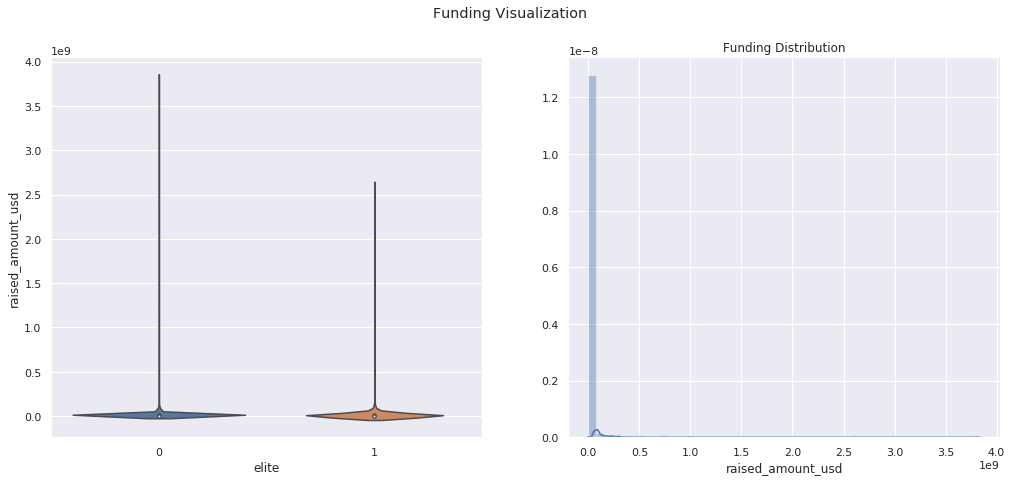

```python
plt.figure(figsize = (17,7))
plt.subplot(1,2,1)
sns.violinplot(x = 'elite', y = 'raised_amount_usd', data = df)
plt.title('')

plt.subplot(1,2,2)
sns.distplot(df['raised_amount_usd'])
plt.title('Funding Distribution')

plt.suptitle('Funding Visualization')

plt.show()
```

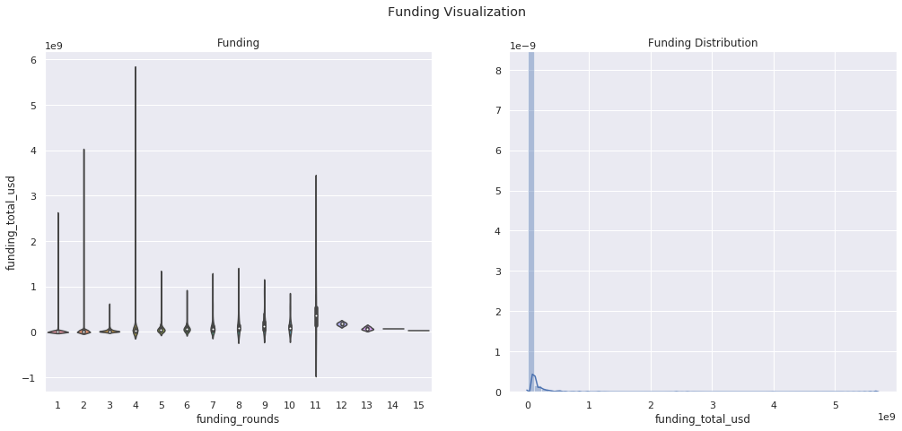

```python
plt.figure(figsize = (17,7))
plt.subplot(1,2,1)
sns.violinplot(x = 'funding_rounds', y = 'funding_total_usd', data = df)
plt.title('Funding')

plt.subplot(1,2,2)
sns.distplot(df['funding_total_usd'])
plt.title('Funding Distribution')

plt.suptitle('Funding Visualization')

plt.show()
```

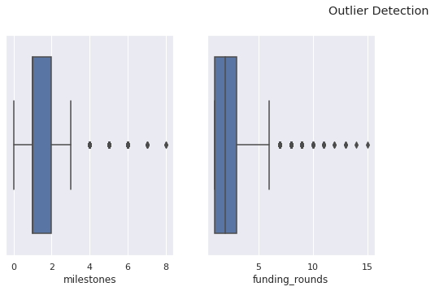

```python
columns = ['milestones','funding_rounds']

plt.figure(figsize = (17, 5))
for i, j in enumerate(columns, 1):
    plt.subplot(1, 4, i)
    sns.boxplot(df[j])

plt.suptitle('Outlier Detection')
plt.show()
```

```python
# drop ID columns,description columns, and irrelevant columns
df.drop(columns=['first_investment_at','last_investment_at','id','entity_type','name','invested_companies','first_funding_at',
                 'first_milestone_at','last_milestone_at','office_id','description','address1','country_code','funded_at',
                 'funding_round_type','raised_amount','raised_currency_code','pre_money_valuation','pre_money_currency_code',
                 'post_money_valuation','post_money_currency_code','source_description','object_id','start_at','end_at','is_past',
                 'degree_type','graduated_at'],axis=1, inplace=True)
```

```python
# drop latitude and longitude
df.drop(columns=['latitude','longitude'],axis=1, inplace=True)
```

```python
# check for missing data and null values
total_missing = df.isnull().sum().sort_values(ascending=False)
percent_missing = (df.isnull().sum()/df.isnull().count()).sort_values(ascending=False)
missing_data = pd.concat([total_missing, percent_missing], axis=1, keys=['Total', 'Percent'])
missing_data.head(10)
```

|  | Total | Percent |
| --- | --- | --- |
| closed_at | 7185 | 0.970946 |
| state_code | 1881 | 0.254189 |
| zip_code | 1071 | 0.144730 |
| founded_at | 874 | 0.118108 |
| city | 172 | 0.023243 |
| category_code | 136 | 0.018378 |
| last_funding_at | 15 | 0.002027 |
| elite | 0 | 0.000000 |
| milestones | 0 | 0.000000 |
| entity_id | 0 | 0.000000 |

```python
df.head()
```

|  | institution | entity_id | category_code | status | founded_at | closed_at | investment_rounds | last_funding_at | funding_rounds | funding_total_usd | milestones | relationships | region | city | zip_code | state_code | funding_round_code | raised_amount_usd | pre_money_valuation_usd | post_money_valuation_usd | participants | is_first_round | is_last_round | sequence | elite |
| --- | --- | --- | --- | --- | --- | --- | --- | --- | --- | --- | --- | --- | --- | --- | --- | --- | --- | --- | --- | --- | --- | --- | --- | --- | --- |
| 0 | Yale University | 10015 | health | operating | 2007-10-01 | NaN | 0 | 2013-08-13 | 5 | 68069200 | 0 | 14 | SF Bay | San Francisco | 94105-1503 | CA | unattributed | 2069200.0 | 0.0 | 0.0 | 4 | 0 | 0 | 4 | True |
| 2 | Rider University | 10018 | analytics | operating | 2006-01-01 | NaN | 0 | 2013-03-28 | 3 | 33000000 | 3 | 19 | SF Bay | San Francisco | 94105 | CA | d | 15000000.0 | 0.0 | 0.0 | 6 | 1 | 0 | 1 | False |
| 5 | Norwegian School of Mangement | 100243 | manufacturing | operating | 2004-01-01 | NaN | 0 | 2013-04-08 | 2 | 0 | 0 | 4 | Houston | Houston | 77042 | TX | unattributed | 0.0 | 0.0 | 0.0 | 5 | 1 | 0 | 2 | False |
| 6 | University of Washington | 100271 | enterprise | operating | 2004-01-01 | NaN | 0 | 2011-09-06 | 1 | 1500000 | 1 | 8 | Seattle | Bellevue | 98004 | WA | a | 1500000.0 | 0.0 | 0.0 | 1 | 1 | 1 | 1 | False |
| 8 | University of Notre Dame | 100379 | ecommerce | operating | 2004-01-01 | NaN | 0 | 2011-09-06 | 1 | 0 | 1 | 9 | Seattle | Bellevue | 98004 | WA | unattributed | 0.0 | 0.0 | 0.0 | 1 | 1 | 1 | 1 | False |

```python
df.info()
```

```
<class 'pandas.core.frame.DataFrame'>
Int64Index: 7400 entries, 0 to 13089
Data columns (total 25 columns):
institution                 7400 non-null object
entity_id                   7400 non-null int64
category_code               7264 non-null object
status                      7400 non-null object
founded_at                  6526 non-null datetime64[ns]
closed_at                   215 non-null object
investment_rounds           7400 non-null int64
last_funding_at             7385 non-null datetime64[ns]
funding_rounds              7400 non-null int64
funding_total_usd           7400 non-null int64
milestones                  7400 non-null int64
relationships               7400 non-null int64
region                      7400 non-null object
city                        7228 non-null object
zip_code                    6329 non-null object
state_code                  5519 non-null object
funding_round_code          7400 non-null object
raised_amount_usd           7400 non-null float64
pre_money_valuation_usd     7400 non-null float64
post_money_valuation_usd    7400 non-null float64
participants                7400 non-null int64
is_first_round              7400 non-null int64
is_last_round               7400 non-null int64
sequence                    7400 non-null int64
elite                       7400 non-null object
dtypes: datetime64[ns](2), float64(3), int64(10), object(10)
memory usage: 1.5+ MB
```

```python
# drop columns for irrelevant features and duplicate date columns as feature is in another column
df.drop(columns=['entity_id','founded_at','last_funding_at','sequence','institution'],axis=1, inplace=True)
```

```python
# check for missing data and null values
total_missing = df.isnull().sum().sort_values(ascending=False)
percent_missing = (df.isnull().sum()/df.isnull().count()).sort_values(ascending=False)
missing_data = pd.concat([total_missing, percent_missing], axis=1, keys=['Total', 'Percent'])
missing_data.head(10)
```

|  | Total | Percent |
| --- | --- | --- |
| closed_at | 7185 | 0.970946 |
| state_code | 1881 | 0.254189 |
| zip_code | 1071 | 0.144730 |
| city | 172 | 0.023243 |
| category_code | 136 | 0.018378 |
| pre_money_valuation_usd | 0 | 0.000000 |
| raised_amount_usd | 0 | 0.000000 |
| funding_round_code | 0 | 0.000000 |
| post_money_valuation_usd | 0 | 0.000000 |
| participants | 0 | 0.000000 |

```python
df.describe()
```

|  | investment_rounds | funding_rounds | funding_total_usd | milestones | relationships | raised_amount_usd | pre_money_valuation_usd | post_money_valuation_usd | participants | is_first_round | is_last_round |
| --- | --- | --- | --- | --- | --- | --- | --- | --- | --- | --- | --- |
| count | 7400.000000 | 7400.000000 | 7.400000e+03 | 7400.000000 | 7400.000000 | 7.400000e+03 | 7.400000e+03 | 7.400000e+03 | 7400.000000 | 7400.000000 | 7400.000000 |
| mean | 0.226622 | 2.137027 | 2.488957e+07 | 1.513919 | 9.157703 | 1.152999e+07 | 1.652973e+05 | 4.150682e+06 | 1.788649 | 0.838919 | 0.570135 |
| std | 6.866803 | 1.555873 | 1.151901e+08 | 1.146551 | 21.825293 | 7.423729e+07 | 7.843028e+06 | 1.436791e+08 | 2.392872 | 0.367631 | 0.495090 |
| min | 0.000000 | 1.000000 | 0.000000e+00 | 0.000000 | 1.000000 | 0.000000e+00 | 0.000000e+00 | 0.000000e+00 | 0.000000 | 0.000000 | 0.000000 |
| 25% | 0.000000 | 1.000000 | 5.745000e+05 | 1.000000 | 3.000000 | 2.741250e+05 | 0.000000e+00 | 0.000000e+00 | 0.000000 | 1.000000 | 0.000000 |
| 50% | 0.000000 | 2.000000 | 4.493455e+06 | 1.000000 | 5.000000 | 2.000000e+06 | 0.000000e+00 | 0.000000e+00 | 1.000000 | 1.000000 | 1.000000 |
| 75% | 0.000000 | 3.000000 | 2.000000e+07 | 2.000000 | 11.000000 | 8.437500e+06 | 0.000000e+00 | 0.000000e+00 | 3.000000 | 1.000000 | 1.000000 |
| max | 478.000000 | 15.000000 | 5.700000e+09 | 8.000000 | 1046.000000 | 3.835050e+09 | 5.500000e+08 | 1.000000e+10 | 36.000000 | 1.000000 | 1.000000 |

```python
df['category_code'].value_counts()
```

```python
# remove redundant geographic columns
df['city'].value_counts(), df['state_code'].value_counts(), df['region'].value_counts()
```

```python
# drop zipcode as too specific and redundant with city
df.drop(columns=['zip_code','state_code'],axis=1, inplace=True)
```

```python
# drop rows with missing values
df =df[df['category_code'].notnull()]
```

```python
# drop rows with missing values
df =df[df['city'].notnull()]
```

```python
df =df[df['elite'].notnull()]
```

```python
df.info()
```

```
<class 'pandas.core.frame.DataFrame'>
Int64Index: 7100 entries, 0 to 13089
Data columns (total 18 columns):
category_code               7100 non-null object
status                      7100 non-null object
closed_at                   207 non-null object
investment_rounds           7100 non-null int64
funding_rounds              7100 non-null int64
funding_total_usd           7100 non-null int64
milestones                  7100 non-null int64
relationships               7100 non-null int64
region                      7100 non-null object
city                        7100 non-null object
funding_round_code          7100 non-null object
raised_amount_usd           7100 non-null float64
pre_money_valuation_usd     7100 non-null float64
post_money_valuation_usd    7100 non-null float64
participants                7100 non-null int64
is_first_round              7100 non-null int64
is_last_round               7100 non-null int64
elite                       7100 non-null object
dtypes: float64(3), int64(8), object(7)
memory usage: 1.0+ MB
```

```python
#numeric columns
numeric_columns = df.select_dtypes(['int64', 'float64']).columns
print(numeric_columns)
print("The number of numerical columns is {}".format(len(numeric_columns)))
```

[output not shown]

```python
# non-numeric columns
non_numeric_columns = df.select_dtypes(['object']).columns
print(non_numeric_columns)
print("The number of non-numerical columns is {}".format(len(non_numeric_columns)))
```

[output not shown]

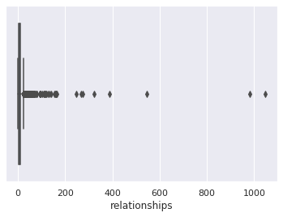

```python
# check for outliers
plt.figure(figsize=(6,4))
sns.boxplot(df['relationships'])
```

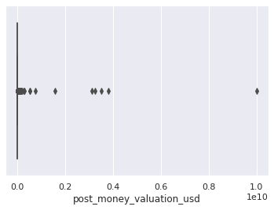

```python
# check for outliers
plt.figure(figsize=(6,4))
sns.boxplot(df['post_money_valuation_usd'])
```

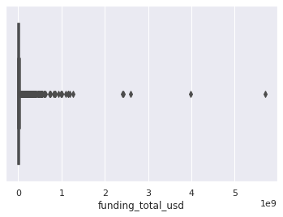

```python
# check for outliers
plt.figure(figsize=(6,4))
sns.boxplot(df['funding_total_usd'])
plt.show;
```

```python
# check for outliers
plt.figure(figsize=(6,4))
sns.boxenplot(df['milestones'])
plt.show;
```

[output not shown]

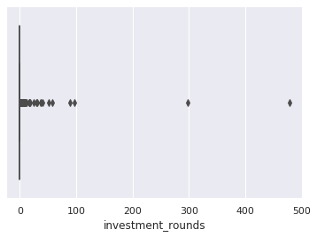

```python
# check for outliers
plt.figure(figsize=(6,4))
sns.boxplot(df['investment_rounds'])
```

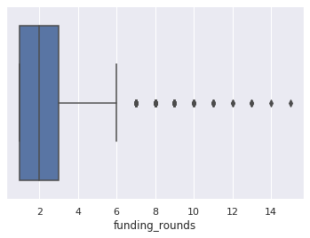

```python
# check for outliers
plt.figure(figsize=(6,4))
sns.boxplot(df['funding_rounds'])
```

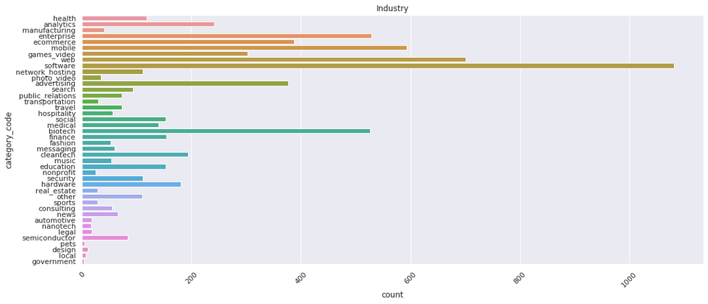

```python
# View the sectors
plt.figure(figsize = (17,7))
sns.countplot(y = 'category_code', data = df)
plt.xticks(rotation = 45)
plt.title('Industry')
plt.show()
```

```python
df.describe()
```

[output not shown]

```python
from scipy.stats.mstats import winsorize

# # We apply one-way winsorization to the highest end
# # of the value distribution. As we have a lot of extreme
# # values, we set the values of the outliers to the
# # value of the 80th percentile.
df['relationships'] = winsorize(df['relationships'], (0, 0.90))
```

```python
df['investment_rounds'].idxmax()
```

```
5685
```

```python
df = df.drop(index=[5685])
```

```python
df['investment_rounds'].idxmax()
```

```python
df = df.drop(index=[11829])
```

```python
df.describe()
```

|  | investment_rounds | funding_rounds | funding_total_usd | milestones | relationships | raised_amount_usd | pre_money_valuation_usd | post_money_valuation_usd | participants | is_first_round | is_last_round |
| --- | --- | --- | --- | --- | --- | --- | --- | --- | --- | --- | --- |
| count | 7095.000000 | 7095.000000 | 7.095000e+03 | 7095.000000 | 7095.000000 | 7.095000e+03 | 7.095000e+03 | 7.095000e+03 | 7095.000000 | 7095.000000 | 7095.000000 |
| mean | 0.091755 | 2.168992 | 2.541252e+07 | 1.533192 | 1.927273 | 1.159638e+07 | 1.724031e+05 | 4.116967e+06 | 1.795208 | 0.836082 | 0.559690 |
| std | 1.299805 | 1.572887 | 1.171011e+08 | 1.149394 | 0.259707 | 7.514933e+07 | 8.009779e+06 | 1.456540e+08 | 2.401879 | 0.370227 | 0.496459 |
| min | 0.000000 | 1.000000 | 0.000000e+00 | 0.000000 | 1.000000 | 0.000000e+00 | 0.000000e+00 | 0.000000e+00 | 0.000000 | 0.000000 | 0.000000 |
| 25% | 0.000000 | 1.000000 | 6.000000e+05 | 1.000000 | 2.000000 | 3.000000e+05 | 0.000000e+00 | 0.000000e+00 | 0.000000 | 1.000000 | 0.000000 |
| 50% | 0.000000 | 2.000000 | 4.700000e+06 | 1.000000 | 2.000000 | 2.000000e+06 | 0.000000e+00 | 0.000000e+00 | 1.000000 | 1.000000 | 1.000000 |
| 75% | 0.000000 | 3.000000 | 2.037500e+07 | 2.000000 | 2.000000 | 8.545000e+06 | 0.000000e+00 | 0.000000e+00 | 3.000000 | 1.000000 | 1.000000 |
| max | 51.000000 | 15.000000 | 5.700000e+09 | 8.000000 | 2.000000 | 3.835050e+09 | 5.500000e+08 | 1.000000e+10 | 36.000000 | 1.000000 | 1.000000 |

# Feature Engineering

```python
# Correlation Matrix
df.corr()
```

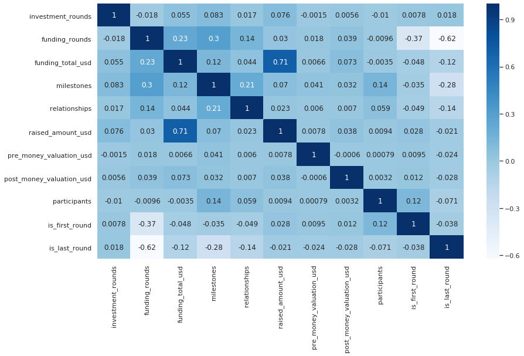

```python
# Correlation heatmap
plt.subplots(figsize=(14,8))
ax = plt.axes()
corr = df.corr()
sns.heatmap(corr,
            xticklabels=corr.columns.values,
            yticklabels=corr.columns.values,
           cmap = "Blues",annot=True)
```

```python
# elite from boolean to integers
df['elite'] = df['elite'].astype(int)
```

```python
df['closed_at'] = np.where(df['closed_at'].notnull(), 1, 0)
```

```python
df['closed_at'].value_counts()
```

```
0    6888
1     207
Name: closed_at, dtype: int64
```

```python
df.drop('closed_at',1, inplace=True)
```

```python
df.info()
```

```
<class 'pandas.core.frame.DataFrame'>
Int64Index: 7095 entries, 0 to 13089
Data columns (total 17 columns):
category_code               7095 non-null object
status                      7095 non-null object
investment_rounds           7095 non-null int64
funding_rounds              7095 non-null int64
funding_total_usd           7095 non-null int64
milestones                  7095 non-null int64
relationships               7095 non-null int64
region                      7095 non-null object
city                        7095 non-null object
funding_round_code          7095 non-null object
raised_amount_usd           7095 non-null float64
pre_money_valuation_usd     7095 non-null float64
post_money_valuation_usd    7095 non-null float64
participants                7095 non-null int64
is_first_round              7095 non-null int64
is_last_round               7095 non-null int64
elite                       7095 non-null int64
dtypes: float64(3), int64(9), object(5)
memory usage: 997.7+ KB
```

```python
# save merged dataframe for easier use
from google.colab import files
df.to_csv('df.csv')
files.download('df.csv')
```

# Separate Categorical and Continuous Features

```python
# categorical dataframe for dimensionality reduction
cat_f = pd.DataFrame(data= df, columns=['category_code', 'region', 'city','funding_round_code'])
cat_fd = pd.get_dummies(cat_f,columns=['category_code', 'region', 'city','funding_round_code'],drop_first = True)
cat_fd.shape
```

```
(7095, 2116)
```

```python
# continuous variable dataframe for dimensionality reduction
con_f = pd.DataFrame(data= df, columns=['investment_rounds', 'funding_rounds', 'funding_total_usd',
       'milestones', 'relationships', 'raised_amount_usd',
       'pre_money_valuation_usd', 'post_money_valuation_usd', 'participants',
       'is_first_round', 'is_last_round', 'elite'])
con_f.shape
```

```
(7095, 12)
```

# Can we distinguish the classes from unlabeled data applying various Dimensionality Reduction methods and then applying Clustering Models?

```python
df['status'].value_counts()
```

```
operating    5906
acquired      742
ipo           247
closed        200
Name: status, dtype: int64
```

# Transform Data for use in ML

```python
# assign the features and label for categorical
Xc = cat_fd

# view the shape of the array
Xc.shape
```

```
(7095, 2116)
```

```python
# standarizing the features for categorical
scalerc = StandardScaler()
Xc_std = scalerc.fit_transform(Xc)
```

```python
# assign the features for continuous
Xcv = con_f

# view the shape of the array
Xcv.shape
```

```
(7095, 12)
```

```python
# standarizing the features for continuous
scalercv = StandardScaler()
Xcv_std = scalercv.fit_transform(Xcv)
```

# Additional Transformation for use in ML

```python
con_f.shape, mcat.shape
```

```
((7095, 12), (7095, 2))
```

```python
pcat.shape
```

```
(7095, 8)
```

```python
mcat_r = mcat.reset_index(drop = True)
```

```python
pca_r = pcat.reset_index(drop=True)
```

```python
con_r = con_f.reset_index(drop = True)
```

```python
# combine df after dimensionality reduction on categorical variables
df = pd.concat([con_r,mcat_r], axis = 1)
df.shape
```

```
(7095, 14)
```

```python
 # assign the features for combined
X1 = df
X1.shape
```

```
(7095, 14)
```

```python
# standarizing the features for combined df
scaler1 = StandardScaler()
X1_std = scaler1.fit_transform(X1)
```

## Future Analysis

```python
# future analysis
# assign the features and label for combined
#X = df2.drop('status',1)
# y = df2['status'] # not used in our analysis

# view the shape of the arrays
# print(X.shape, y.shape)
```

```python
# future analysis
# encode into integers
# LE = LabelEncoder()
# y = LE.fit_transform(y)
# # view the shape of the arrays
# print(X.shape, y.shape)
```

# Dimensionality Reduction

## t-SNE

Notes: The way t-SNE minimizes the divergence between two distributions by emphasizing local similarities, makes it suitable for visualization purposes only, not feature engineering.

Perplexity balances the attention t-SNE gives to local and global aspects of the data and can have large effects on the resulting plot

Important points to consider t-SNE is not a clustering algorithm but a dimensionality reduction algorithm. Hence we shouldn't make any inference based only on the output of t-SNE. We use it mainly for data exploration and visualization. Cluster sizes in t-SNE plots must not be evaluated for variance or dispersion. Because, t-SNE expands denser clusters and contracts sparser clusters to make them similar sized. This is one of the reasons for the clear plots it produces.

If we have variables of different scales and we want t-SNE to treat each variable equally, then standardizing the features before applying t-SNE is important. Especially the L2 norm (Euclidean distance) is sensitive to the scaling of the data.

```python
tsne = TSNE(n_components=5, verbose=1,perplexity= 40, n_iter=1000)
tsne_x = tsne.fit_transform(X1_std)
```

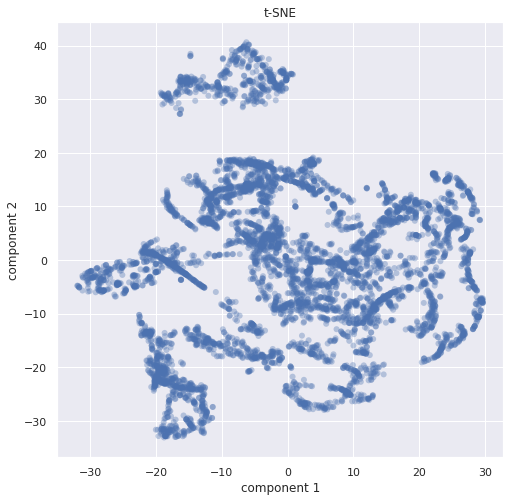

```python
sns.set()
plt.figure(figsize=(8, 8))
plt.scatter(tsne_x[:,0],tsne_x[:,1],
            cmap = "viridis", edgecolor = "None", alpha=0.35)
plt.xlabel('component 1')
plt.ylabel('component 2')
plt.title('t-SNE');
```

We can see from the scatter plot that t-SNE shows a little separation of classes with some distinct blobs

## MCA on Categorical Features Only

```python
# MCA
mca = prince.MCA(n_components=2, n_iter=3, copy=True, engine='auto', random_state=42)
mcac = mca.fit(cat_f)
mcat = mca.transform(cat_f)
```

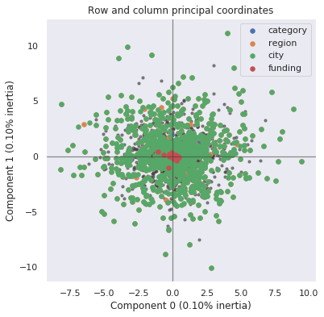

```python
ax = mca.plot_coordinates(
     X=cat_f,
     ax=None,
     figsize=(6, 6),
     show_row_points=True,
     row_points_size=10,
     show_row_labels=False,
     show_column_points=True,
     column_points_size=30,
     show_column_labels=False,
     legend_n_cols=1
)
```

```python
mcac.eigenvalues_, mcac.total_inertia_
```

```
([0.5275748408647721, 0.5112416052033338], 529.0)
```

```python
# explained interia: percentage of variance explained by eigenvector
mcac.explained_inertia_
```

```
[0.0009973059373625183, 0.0009664302555828617]
```

Multiple correspondence analysis (MCA) is an extension of correspondence analysis (CA). It should be used when you have more than two categorical variables. The idea is simply to compute the one-hot encoded version of a dataset and apply CA on it. Percentage of variance explained by an Eigenvector is also referred as its inertia.

## PCA on Continuous Features Only

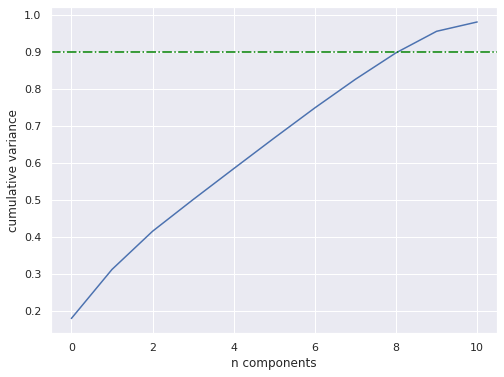

```python
# Visualize on continuous only
plt.figure(figsize=(8,6))
pca = PCA(11).fit(Xcv_std)
plt.plot(np.cumsum(pca.explained_variance_ratio_))
plt.xlabel('n components')
plt.axhline(0.90, color='green', linestyle='-.')
plt.ylabel('cumulative variance');
explained_variance = pca.explained_variance_ratio_
```

```python
print(explained_variance)
```

```
[0.17992067 0.13240682 0.10326004 0.08570496 0.08356962 0.08290596
 0.08136976 0.07731744 0.07148755 0.05815339 0.02521647]
```

```python
# pca on continuous only
pca = PCA(n_components = 2)
pca_2c = pca.fit_transform(Xcv_std)
print(Xcv_std.shape)
print(pca_2c.shape)
```

```
(7095, 12)
(7095, 2)
```

```python
# pca on continuous only
pca = PCA(n_components=8)  # project from 12 to 2 dimensions
x_pca8= pca.fit_transform(Xcv_std)
print(Xcv_std.shape)
print(x_pca8.shape)
```

```
(7095, 12)
(7095, 8)
```

```python
pca8 = pca.transform(Xcv_std)
pcat = pd.DataFrame(pca8)
pcat.shape
```

```
(7095, 8)
```

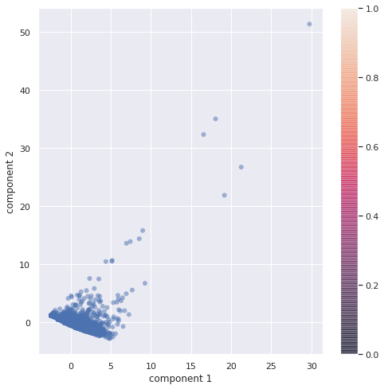

```python
plt.figure(figsize=(8,8))
plt.scatter(x_pca8[:, 0], x_pca8[:, 1],
            edgecolor='none', alpha=0.5,
            cmap=plt.cm.get_cmap('Spectral', 10))
plt.xlabel('component 1')
plt.ylabel('component 2')
plt.colorbar();
```

```python
# explained variance of 2 components
explained_variance = pca.explained_variance_ratio_
print(explained_variance)
```

```
[0.17992067 0.13240682 0.10326004 0.08570496 0.08356962 0.08290596
 0.08136976 0.07731744]
```

Based on the scatter plot of 2 components, PCA does a poor job of separating the classes using only the continuous variables.

## Factor analysis of mixed data (FAMD)

When data include both numeric and categorical variables and the active variables are homogeneous, i.e, there is no dependence between numeric and categorical variables, PCA or MCA can be used.

When the active variables are mixed, the usual practice is to perform discretization on the quantitative variables (e.g. usually in surveys the age is transformed into age classes). Data thus obtained can be processed by MCA.

```python
df.info()
```

[output not shown]

```python
dff = df
famd = prince.FAMD(n_components=2,n_iter=3,copy=True,check_input=True,engine='auto',random_state=42)
famd = famd.fit(dff.drop('status', axis=1))
```

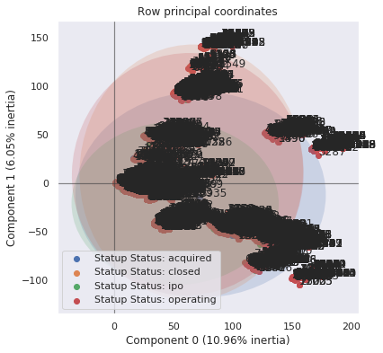

```python
ax = famd.plot_row_coordinates(
     dff,
     ax=None,
     figsize=(6, 6),
     x_component=0,
     y_component=1,
     labels=df.index,
     color_labels=['Statup Status: {}'.format(t) for t in df['status']],
     ellipse_outline=False,
     ellipse_fill=True,
     show_points=True
)
```

## UMAP

Notes: Consider the two most commonly used parameters: n_neighbors and min_dist, which are effectively used to control the balance between local and global structure in the final projection. The most important parameter is n_neighbors - the number of approximate nearest neighbors used to construct the initial high-dimensional graph. n_neighbors effectively controls how UMAP balances local versus global structure. Low values will push UMAP to focus more on local structure by constraining the number of neighboring points considered when analyzing the data in high dimensions. High values will push UMAP towards representing the big-picture structure while losing fine detail. min_dist is the minimum distance between points in low-dimensional space. min_dist controls how tightly UMAP clumps points together. Low values lead to more tightly packed embeddings. Larger values of min_dist will make UMAP pack points together more loosely, focusing instead on the preservation of the broad topological structure.

Notes: The biggest difference between the the output of UMAP when compared with t-SNE is this balance between local and global structure. UMAP is often better at preserving global structure in the final projection. This means that the inter-cluster relations are potentially more meaningful than in t-SNE. Because UMAP and t-SNE both warp the high-dimensional shape of the data when projecting to lower dimensions, any given axis or distance in lower dimensions still isn’t directly interpretable in the way of techniques such as PCA.

```python
umap1 = umap.UMAP(n_neighbors=99, min_dist=.3, metric='euclidean')
umap_X = umap1.fit_transform(X1_std)
```

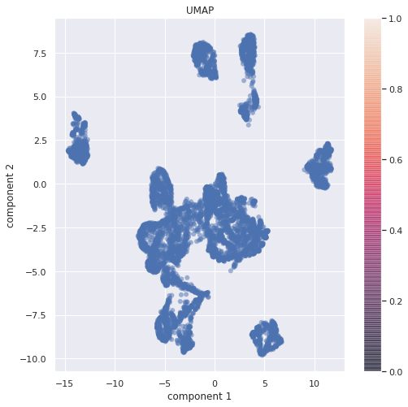

```python
sns.set()
plt.figure(figsize=(8, 8))
plt.scatter(umap_X[:, 0], umap_X[:, 1],
            edgecolor='none', alpha=0.5,
            cmap=plt.cm.get_cmap('Spectral', 3))
plt.xlabel('component 1')
plt.ylabel('component 2')
plt.title('UMAP')
plt.colorbar();
```

1 large blob, 2 medium size and 3 small that may indicate Startups that are operating, ipo, acquired, and closed.

# Isomap

Isomap (Isometric Feature Mapping), unlike Principle Component Analysis, is a non-linear feature reduction method.

Notes: Manifold Learning can be thought of as an attempt to generalize linear frameworks like PCA to be sensitive to non-linear structure in data. Typical manifold learning problems are unsupervised. Isomap is short for Isometric Mapping. Isomap can be viewed as an extension of Kernel PCA. Isomap seeks a lower-dimensional embedding which maintains geodesic distances between all points. The geodesic distance between two vertices in a graph is the number of edges in a shortest path connecting them.

nearest neighbor with the shortest path.

```python
# Isomap on reduced component cat and continuous
iso_model = manifold.Isomap(n_neighbors=11, n_components=2)
iso_x = iso_model.fit_transform(X3_std)
iso_df = pd.DataFrame(iso_x, columns=['Component 1', 'Component 2'])

# Left with 2 dimensions
iso_df.head()
```

|  | Component 1 | Component 2 |
| --- | --- | --- |
| 0 | -6.506664 | -1.294516 |
| 1 | -4.412743 | -9.246831 |
| 2 | 47.609658 | 6.096286 |
| 3 | -11.700468 | 0.042325 |
| 4 | -10.084157 | 0.609776 |

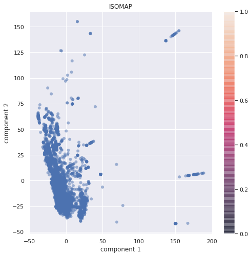

```python
sns.set()
plt.figure(figsize=(8, 8))
plt.scatter(iso_x[:, 0], iso_x[:, 1],
            edgecolor='none', alpha=0.5,
            )
plt.xlabel('component 1')
plt.ylabel('component 2')
plt.title('ISOMAP')
# centers = iso_model.cluster_centers_
# plt.scatter(centers[:, 0], centers[:, 1], marker='*', c='black', s=200, alpha=0.5)
plt.colorbar();
```

# Clustering Algorithms

- Dimensionality Reduction: UMAP

## K-means

K-means is an iterative algorithm that eventually converges on a solution. The basic idea in k-means is to find the best k points that form the centers of the k clusters.

NOTES:

K-means is an iterative algorithm that eventually converges on a solution. The basic idea in k-means is to find the best k points that form the centers of the k clusters. These points are called centroids. The algorithm begins by choosing k observations at random and making these observations initial centroids. Then it iterates over the following two steps:

Assign each data point to its nearest centroid. Create new centroids by taking the mean of all the data points assigned to each centroid. The algorithm stops when the difference between the old and the new centroids is lower than a given threshold value.

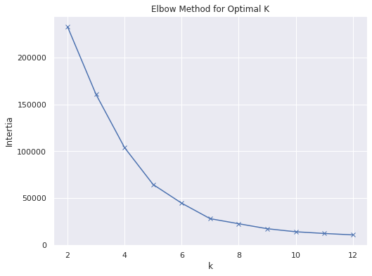

```python
inertia = []
K = range(2,13,1)
for k in K:
    kmeans = KMeans(n_clusters=k).fit(umap_X)
    inertia.append(kmeans.inertia_)
plt.figure(figsize=(8,6))
plt.plot(K,inertia,'bx-')
plt.xlabel('k')
plt.ylabel('Intertia')
plt.title('Elbow Method for Optimal K')
plt.show()
```

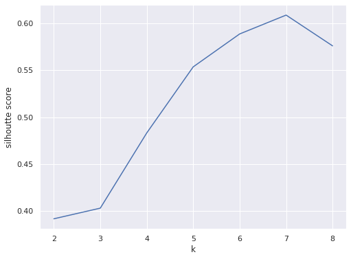

```python
# silhoutte score
s_score = []
K = range(2,9,1)
for k in K:
    kmeans = KMeans(n_clusters=k).fit(umap_X)
    y_pred = kmeans.fit_predict(umap_X)
    silhouette_score(umap_X, y_pred)
    s_score.append(silhouette_score(umap_X, y_pred))
plt.figure(figsize=(8,6))
plt.plot(K,s_score)
plt.xlabel('k')
plt.ylabel('silhoutte score')
plt.show()
```

K-means on UMAP Data

```python
#start timer
t = time.process_time()

k_means = KMeans(n_clusters=7, init='random',random_state=123, n_jobs = -1)
y_pred = k_means.fit_predict(umap_X)

#end timer
elapsed_time = time.process_time() - t
print('Duration: {}'.format(elapsed_time))
```

```
Duration: 0.10443594299999859
```

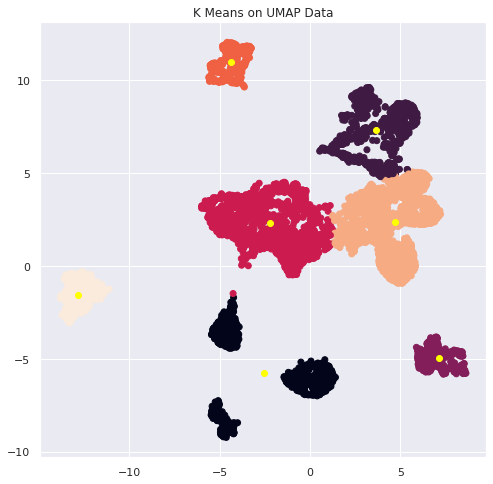

```
Silhouette Score: 0.5888451933860779
```

```python
# Plot the kmeans
plt.figure(figsize = (8,8))
plt.scatter(umap_X[:,0], umap_X[:,1], c = y_pred)
centers = k_means.cluster_centers_
plt.scatter(centers[:, 0], centers[:, 1], c='yellow');
plt.title('K Means on UMAP Data')
plt.show();

umap_k_means_labels = k_means.labels_
umap_k_means_cluster_centers = k_means.cluster_centers_

print('Silhouette Score: {}'.format(silhouette_score(umap_X, y_pred)))
```

```python
df['UMAP Kmeans Cluster'] = umap_k_means_labels
df['UMAP Kmeans Cluster Str'] = df['UMAP Kmeans Cluster'].astype(str)
```

```python
cluster0_df = df.loc[df['UMAP Kmeans Cluster']==0]
cluster1_df = df.loc[df['UMAP Kmeans Cluster']==1]
cluster2_df = df.loc[df['UMAP Kmeans Cluster']==2]
cluster3_df = df.loc[df['UMAP Kmeans Cluster']==3]
cluster4_df = df.loc[df['UMAP Kmeans Cluster']==4]
cluster5_df = df.loc[df['UMAP Kmeans Cluster']==5]
cluster6_df = df.loc[df['UMAP Kmeans Cluster']==6]
```

```python
cluster0_df.describe(include = 'O')
```

|  | category_code | status | region | city | funding_round_code | UMAP Kmeans Cluster Str |
| --- | --- | --- | --- | --- | --- | --- |
| count | 1069 | 1069 | 1069 | 1069 | 1069 | 1069 |
| unique | 40 | 4 | 148 | 319 | 16 | 1 |
| top | software | operating | SF Bay | San Francisco | unattributed | 0 |
| freq | 163 | 869 | 349 | 131 | 261 | 1069 |

```python
cluster0_df.describe()
```

|  | Unnamed: 0 | closed_at | investment_rounds | funding_rounds | funding_total_usd | milestones | relationships | raised_amount_usd | pre_money_valuation_usd | post_money_valuation_usd | participants | is_first_round | is_last_round | elite | UMAP Kmeans Cluster | funding_p_rd | participants_p_rd |
| --- | --- | --- | --- | --- | --- | --- | --- | --- | --- | --- | --- | --- | --- | --- | --- | --- | --- |
| count | 1069.000000 | 1069.000000 | 1069.000000 | 1069.000000 | 1.069000e+03 | 1069.000000 | 1069.0 | 1.069000e+03 | 1069.0 | 1.069000e+03 | 1069.000000 | 1069.000000 | 1069.000000 | 1069.000000 | 1069.0 | 1.069000e+03 | 1069.000000 |
| mean | 6376.369504 | 0.016838 | 0.011225 | 3.565949 | 3.318069e+07 | 1.660430 | 2.0 | 5.635356e+06 | 0.0 | 1.432426e+04 | 1.125351 | 0.000935 | 0.589336 | 0.221703 | 0.0 | 8.460933e+06 | 0.432718 |
| std | 3811.471746 | 0.128725 | 0.105403 | 1.894354 | 5.731186e+07 | 1.150532 | 0.0 | 1.150565e+07 | 0.0 | 4.683397e+05 | 1.665131 | 0.030585 | 0.492185 | 0.415586 | 0.0 | 1.303491e+07 | 0.711813 |
| min | 0.000000 | 0.000000 | 0.000000 | 1.000000 | 0.000000e+00 | 0.000000 | 2.0 | 0.000000e+00 | 0.0 | 0.000000e+00 | 0.000000 | 0.000000 | 0.000000 | 0.000000 | 0.0 | 0.000000e+00 | 0.000000 |
| 25% | 2875.000000 | 0.000000 | 0.000000 | 2.000000 | 4.050000e+06 | 1.000000 | 2.0 | 4.000000e+05 | 0.0 | 0.000000e+00 | 0.000000 | 0.000000 | 0.000000 | 0.000000 | 0.0 | 1.433533e+06 | 0.000000 |
| 50% | 6280.000000 | 0.000000 | 0.000000 | 3.000000 | 1.564000e+07 | 2.000000 | 2.0 | 2.000000e+06 | 0.0 | 0.000000e+00 | 1.000000 | 0.000000 | 1.000000 | 0.000000 | 0.0 | 5.000000e+06 | 0.142857 |
| 75% | 9656.000000 | 0.000000 | 0.000000 | 4.000000 | 3.970000e+07 | 2.000000 | 2.0 | 6.073670e+06 | 0.0 | 0.000000e+00 | 2.000000 | 0.000000 | 1.000000 | 0.000000 | 0.0 | 1.086600e+07 | 0.500000 |
| max | 13066.000000 | 1.000000 | 1.000000 | 15.000000 | 6.050080e+08 | 6.000000 | 2.0 | 2.000000e+08 | 0.0 | 1.531263e+07 | 12.000000 | 1.000000 | 1.000000 | 1.000000 | 0.0 | 2.390000e+08 | 6.000000 |

```python
cluster1_df.describe(include = 'O')
```

|  | category_code | status | region | city | funding_round_code | UMAP Kmeans Cluster Str |
| --- | --- | --- | --- | --- | --- | --- |
| count | 1049 | 1049 | 1049 | 1049 | 1049 | 1049 |
| unique | 40 | 4 | 127 | 288 | 17 | 1 |
| top | software | operating | SF Bay | San Francisco | seed | 1 |
| freq | 169 | 792 | 318 | 160 | 402 | 1049 |

```python
cluster1_df.describe()
```

|  | Unnamed: 0 | closed_at | investment_rounds | funding_rounds | funding_total_usd | milestones | relationships | raised_amount_usd | pre_money_valuation_usd | post_money_valuation_usd | participants | is_first_round | is_last_round | elite | UMAP Kmeans Cluster | funding_p_rd | participants_p_rd |
| --- | --- | --- | --- | --- | --- | --- | --- | --- | --- | --- | --- | --- | --- | --- | --- | --- | --- |
| count | 1049.000000 | 1049.000000 | 1049.000000 | 1049.000000 | 1.049000e+03 | 1049.000000 | 1049.000000 | 1.049000e+03 | 1.049000e+03 | 1.049000e+03 | 1049.000000 | 1049.000000 | 1049.000000 | 1049.000000 | 1049.0 | 1.049000e+03 | 1049.000000 |
| mean | 6489.516683 | 0.031459 | 0.467112 | 1.025739 | 1.248107e+07 | 2.018112 | 1.999047 | 1.211846e+07 | 2.478551e+03 | 9.829933e+05 | 2.946616 | 0.997140 | 0.990467 | 0.010486 | 1.0 | 1.188372e+07 | 2.904036 |
| std | 4066.629833 | 0.174637 | 3.286439 | 0.175572 | 3.757240e+07 | 0.864181 | 0.030875 | 3.585221e+07 | 8.027598e+04 | 2.365492e+07 | 3.681371 | 0.053427 | 0.097216 | 0.101912 | 0.0 | 3.493040e+07 | 3.553295 |
| min | 19.000000 | 0.000000 | 0.000000 | 1.000000 | 0.000000e+00 | 0.000000 | 1.000000 | 0.000000e+00 | 0.000000e+00 | 0.000000e+00 | 0.000000 | 0.000000 | 0.000000 | 0.000000 | 1.0 | 0.000000e+00 | 0.000000 |
| 25% | 2704.000000 | 0.000000 | 0.000000 | 1.000000 | 2.500000e+05 | 1.000000 | 2.000000 | 2.500000e+05 | 0.000000e+00 | 0.000000e+00 | 1.000000 | 1.000000 | 1.000000 | 0.000000 | 1.0 | 2.500000e+05 | 1.000000 |
| 50% | 6314.000000 | 0.000000 | 0.000000 | 1.000000 | 1.500000e+06 | 2.000000 | 2.000000 | 1.500000e+06 | 0.000000e+00 | 0.000000e+00 | 2.000000 | 1.000000 | 1.000000 | 0.000000 | 1.0 | 1.500000e+06 | 2.000000 |
| 75% | 10295.000000 | 0.000000 | 0.000000 | 1.000000 | 7.000000e+06 | 2.000000 | 2.000000 | 7.000000e+06 | 0.000000e+00 | 0.000000e+00 | 4.000000 | 1.000000 | 1.000000 | 0.000000 | 1.0 | 7.000000e+06 | 4.000000 |
| max | 13089.000000 | 1.000000 | 51.000000 | 3.000000 | 4.277000e+08 | 7.000000 | 2.000000 | 4.277000e+08 | 2.600000e+06 | 7.500000e+08 | 36.000000 | 1.000000 | 1.000000 | 1.000000 | 1.0 | 4.277000e+08 | 36.000000 |

```python
cluster2_df.describe(include = 'O')
```

|  | category_code | status | region | city | funding_round_code | UMAP Kmeans Cluster Str |
| --- | --- | --- | --- | --- | --- | --- |
| count | 511 | 511 | 511 | 511 | 511 | 511 |
| unique | 39 | 4 | 189 | 304 | 15 | 1 |
| top | software | operating | SF Bay | New York | seed | 2 |
| freq | 105 | 466 | 68 | 23 | 150 | 511 |

```python
cluster2_df.describe()
```

|  | Unnamed: 0 | closed_at | investment_rounds | funding_rounds | funding_total_usd | milestones | relationships | raised_amount_usd | pre_money_valuation_usd | post_money_valuation_usd | participants | is_first_round | is_last_round | elite | UMAP Kmeans Cluster |
| --- | --- | --- | --- | --- | --- | --- | --- | --- | --- | --- | --- | --- | --- | --- | --- |
| count | 511.000000 | 511.000000 | 511.000000 | 511.000000 | 5.110000e+02 | 511.000000 | 511.0 | 5.110000e+02 | 511.0 | 5.110000e+02 | 511.000000 | 511.000000 | 511.000000 | 511.000000 | 511.0 |
| mean | 6172.886497 | 0.052838 | 0.013699 | 1.377691 | 7.182539e+06 | 0.669276 | 1.0 | 5.514700e+06 | 0.0 | 5.014818e+05 | 1.250489 | 0.900196 | 0.814090 | 0.131115 | 2.0 |
| std | 3293.097368 | 0.223928 | 0.269000 | 0.743739 | 2.406337e+07 | 0.712779 | 0.0 | 2.192086e+07 | 0.0 | 8.113626e+06 | 1.777825 | 0.300033 | 0.389415 | 0.337857 | 0.0 |
| min | 38.000000 | 0.000000 | 0.000000 | 1.000000 | 0.000000e+00 | 0.000000 | 1.0 | 0.000000e+00 | 0.0 | 0.000000e+00 | 0.000000 | 0.000000 | 0.000000 | 0.000000 | 2.0 |
| 25% | 3350.500000 | 0.000000 | 0.000000 | 1.000000 | 1.500000e+05 | 0.000000 | 1.0 | 1.000000e+05 | 0.0 | 0.000000e+00 | 0.000000 | 1.000000 | 1.000000 | 0.000000 | 2.0 |
| 50% | 6323.000000 | 0.000000 | 0.000000 | 1.000000 | 1.040000e+06 | 1.000000 | 1.0 | 7.500000e+05 | 0.0 | 0.000000e+00 | 1.000000 | 1.000000 | 1.000000 | 0.000000 | 2.0 |
| 75% | 8822.000000 | 0.000000 | 0.000000 | 2.000000 | 5.181160e+06 | 1.000000 | 1.0 | 4.000000e+06 | 0.0 | 0.000000e+00 | 2.000000 | 1.000000 | 1.000000 | 0.000000 | 2.0 |
| max | 12717.000000 | 1.000000 | 6.000000 | 7.000000 | 2.750000e+08 | 5.000000 | 1.0 | 2.750000e+08 | 0.0 | 1.800000e+08 | 14.000000 | 1.000000 | 1.000000 | 1.000000 | 2.0 |

```python
cluster3_df1.describe(include = 'O')
```

|  | category_code | status | region | city | funding_round_code | UMAP Kmeans Cluster Str |
| --- | --- | --- | --- | --- | --- | --- |
| count | 1945 | 1945 | 1945 | 1945 | 1945 | 1945 |
| unique | 41 | 4 | 216 | 464 | 19 | 1 |
| top | software | operating | SF Bay | San Francisco | unattributed | 3 |
| freq | 245 | 1619 | 558 | 243 | 387 | 1945 |

```python
cluster3_df.describe()
```

|  | Unnamed: 0 | closed_at | investment_rounds | funding_rounds | funding_total_usd | milestones | relationships | raised_amount_usd | pre_money_valuation_usd | post_money_valuation_usd | participants | is_first_round | is_last_round | elite | UMAP Kmeans Cluster |
| --- | --- | --- | --- | --- | --- | --- | --- | --- | --- | --- | --- | --- | --- | --- | --- |
| count | 1945.000000 | 1945.000000 | 1945.000000 | 1945.000000 | 1.945000e+03 | 1945.000000 | 1945.0 | 1.945000e+03 | 1.945000e+03 | 1.945000e+03 | 1945.000000 | 1945.000000 | 1945.000000 | 1945.000000 | 1945.0 |
| mean | 6755.912596 | 0.019537 | 0.044730 | 3.008226 | 4.906674e+07 | 1.954242 | 2.0 | 2.179445e+07 | 4.733162e+05 | 1.293339e+07 | 2.102828 | 0.995887 | 0.006684 | 0.004627 | 3.0 |
| std | 3991.872134 | 0.138439 | 0.396168 | 1.391455 | 2.119728e+08 | 1.239965 | 0.0 | 1.384560e+08 | 1.370048e+07 | 2.747692e+08 | 2.291898 | 0.064018 | 0.081502 | 0.067884 | 0.0 |
| min | 2.000000 | 0.000000 | 0.000000 | 1.000000 | 0.000000e+00 | 0.000000 | 2.0 | 0.000000e+00 | 0.000000e+00 | 0.000000e+00 | 0.000000 | 0.000000 | 0.000000 | 0.000000 | 3.0 |
| 25% | 3005.000000 | 0.000000 | 0.000000 | 2.000000 | 2.700000e+06 | 1.000000 | 2.0 | 1.000000e+06 | 0.000000e+00 | 0.000000e+00 | 0.000000 | 1.000000 | 0.000000 | 0.000000 | 3.0 |
| 50% | 7308.000000 | 0.000000 | 0.000000 | 3.000000 | 1.210000e+07 | 2.000000 | 2.0 | 4.900000e+06 | 0.000000e+00 | 0.000000e+00 | 1.000000 | 1.000000 | 0.000000 | 0.000000 | 3.0 |
| 75% | 10255.000000 | 0.000000 | 0.000000 | 3.000000 | 3.753509e+07 | 3.000000 | 2.0 | 1.300000e+07 | 0.000000e+00 | 0.000000e+00 | 3.000000 | 1.000000 | 0.000000 | 0.000000 | 3.0 |
| max | 13086.000000 | 1.000000 | 9.000000 | 11.000000 | 5.700000e+09 | 8.000000 | 2.0 | 3.835050e+09 | 5.500000e+08 | 1.000000e+10 | 17.000000 | 1.000000 | 1.000000 | 1.000000 | 3.0 |

```python
cluster4_df.describe(include = 'O')
```

|  | category_code | status | region | city | funding_round_code | UMAP Kmeans Cluster Str |
| --- | --- | --- | --- | --- | --- | --- |
| count | 441 | 441 | 441 | 441 | 441 | 441 |
| unique | 36 | 4 | 84 | 172 | 12 | 1 |
| top | software | operating | SF Bay | San Francisco | seed | 4 |
| freq | 74 | 349 | 150 | 71 | 147 | 441 |

```python
cluster4_df.describe()
```

|  | Unnamed: 0 | closed_at | investment_rounds | funding_rounds | funding_total_usd | milestones | relationships | raised_amount_usd | pre_money_valuation_usd | post_money_valuation_usd | participants | is_first_round | is_last_round | elite | UMAP Kmeans Cluster |
| --- | --- | --- | --- | --- | --- | --- | --- | --- | --- | --- | --- | --- | --- | --- | --- |
| count | 441.000000 | 441.000000 | 441.000000 | 441.000000 | 4.410000e+02 | 441.000000 | 441.0 | 4.410000e+02 | 441.0 | 4.410000e+02 | 441.000000 | 441.0 | 441.000000 | 441.0 | 441.0 |
| mean | 6105.841270 | 0.038549 | 0.015873 | 1.002268 | 6.966994e+06 | 1.297052 | 2.0 | 6.935248e+06 | 0.0 | 5.793651e+04 | 2.043084 | 1.0 | 0.997732 | 1.0 | 4.0 |
| std | 3630.560661 | 0.192736 | 0.125126 | 0.047619 | 1.488426e+07 | 0.970106 | 0.0 | 1.487347e+07 | 0.0 | 7.548664e+05 | 2.310146 | 0.0 | 0.047619 | 0.0 | 0.0 |
| min | 26.000000 | 0.000000 | 0.000000 | 1.000000 | 0.000000e+00 | 0.000000 | 2.0 | 0.000000e+00 | 0.0 | 0.000000e+00 | 0.000000 | 1.0 | 0.000000 | 1.0 | 4.0 |
| 25% | 3349.000000 | 0.000000 | 0.000000 | 1.000000 | 2.000000e+05 | 1.000000 | 2.0 | 2.000000e+05 | 0.0 | 0.000000e+00 | 0.000000 | 1.0 | 1.000000 | 1.0 | 4.0 |
| 50% | 5556.000000 | 0.000000 | 0.000000 | 1.000000 | 1.500000e+06 | 1.000000 | 2.0 | 1.500000e+06 | 0.0 | 0.000000e+00 | 1.000000 | 1.0 | 1.000000 | 1.0 | 4.0 |
| 75% | 9291.000000 | 0.000000 | 0.000000 | 1.000000 | 7.000000e+06 | 2.000000 | 2.0 | 7.000000e+06 | 0.0 | 0.000000e+00 | 3.000000 | 1.0 | 1.000000 | 1.0 | 4.0 |
| max | 13056.000000 | 1.000000 | 1.000000 | 2.000000 | 1.250000e+08 | 4.000000 | 2.0 | 1.250000e+08 | 0.0 | 1.500000e+07 | 14.000000 | 1.0 | 1.000000 | 1.0 | 4.0 |

```python
cluster5_df1.describe(include = 'O')
```

|  | category_code | status | region | city | funding_round_code | UMAP Kmeans Cluster Str |
| --- | --- | --- | --- | --- | --- | --- |
| count | 1521 | 1521 | 1521 | 1521 | 1521 | 1521 |
| unique | 40 | 4 | 500 | 731 | 16 | 1 |
| top | software | operating | SF Bay | New York | seed | 5 |
| freq | 255 | 1360 | 178 | 81 | 572 | 1521 |

```python
cluster5_df.describe()
```

|  | Unnamed: 0 | closed_at | investment_rounds | funding_rounds | funding_total_usd | milestones | relationships | raised_amount_usd | pre_money_valuation_usd | post_money_valuation_usd | participants | is_first_round | is_last_round | elite | UMAP Kmeans Cluster |
| --- | --- | --- | --- | --- | --- | --- | --- | --- | --- | --- | --- | --- | --- | --- | --- |
| count | 1521.000000 | 1521.000000 | 1521.000000 | 1521.000000 | 1.521000e+03 | 1521.000000 | 1521.000000 | 1.521000e+03 | 1521.0 | 1.521000e+03 | 1521.000000 | 1521.000000 | 1521.000000 | 1521.000000 | 1521.0 |
| mean | 5853.508876 | 0.038790 | 0.013807 | 1.128863 | 6.362802e+06 | 0.754109 | 1.997370 | 4.857741e+06 | 0.0 | 4.407679e+05 | 0.926364 | 0.979619 | 0.942143 | 0.013149 | 5.0 |
| std | 3501.128164 | 0.193158 | 0.146696 | 0.505719 | 2.197740e+07 | 0.653954 | 0.051231 | 1.311429e+07 | 0.0 | 1.287556e+07 | 1.157854 | 0.141347 | 0.233549 | 0.113951 | 0.0 |
| min | 6.000000 | 0.000000 | 0.000000 | 1.000000 | 0.000000e+00 | 0.000000 | 1.000000 | 0.000000e+00 | 0.0 | 0.000000e+00 | 0.000000 | 0.000000 | 0.000000 | 0.000000 | 5.0 |
| 25% | 2951.000000 | 0.000000 | 0.000000 | 1.000000 | 5.500000e+04 | 0.000000 | 2.000000 | 5.000000e+04 | 0.0 | 0.000000e+00 | 0.000000 | 1.000000 | 1.000000 | 0.000000 | 5.0 |
| 50% | 5389.000000 | 0.000000 | 0.000000 | 1.000000 | 7.200000e+05 | 1.000000 | 2.000000 | 6.500000e+05 | 0.0 | 0.000000e+00 | 1.000000 | 1.000000 | 1.000000 | 0.000000 | 5.0 |
| 75% | 8604.000000 | 0.000000 | 0.000000 | 1.000000 | 4.800000e+06 | 1.000000 | 2.000000 | 4.200000e+06 | 0.0 | 0.000000e+00 | 1.000000 | 1.000000 | 1.000000 | 0.000000 | 5.0 |
| max | 13052.000000 | 1.000000 | 3.000000 | 7.000000 | 5.377791e+08 | 4.000000 | 2.000000 | 3.150000e+08 | 0.0 | 5.000000e+08 | 9.000000 | 1.000000 | 1.000000 | 1.000000 | 5.0 |

```python
cluster6_df.describe(include = 'O')
```

|  | category_code | status | region | city | funding_round_code | UMAP Kmeans Cluster Str |
| --- | --- | --- | --- | --- | --- | --- |
| count | 559 | 559 | 559 | 559 | 559 | 559 |
| unique | 37 | 4 | 63 | 153 | 15 | 1 |
| top | software | operating | SF Bay | San Francisco | unattributed | 6 |
| freq | 70 | 451 | 231 | 99 | 118 | 559 |

```python
cluster6_df.describe()
```

|  | Unnamed: 0 | closed_at | investment_rounds | funding_rounds | funding_total_usd | milestones | relationships | raised_amount_usd | pre_money_valuation_usd | post_money_valuation_usd | participants | is_first_round | is_last_round | elite | UMAP Kmeans Cluster |
| --- | --- | --- | --- | --- | --- | --- | --- | --- | --- | --- | --- | --- | --- | --- | --- |
| count | 559.000000 | 559.000000 | 559.000000 | 559.00000 | 5.590000e+02 | 559.000000 | 559.0 | 5.590000e+02 | 5.590000e+02 | 5.590000e+02 | 559.000000 | 559.000000 | 559.0 | 559.0 | 559.0 |
| mean | 6731.420394 | 0.026834 | 0.048301 | 3.19678 | 3.557009e+07 | 2.010733 | 2.0 | 1.410477e+07 | 5.366726e+05 | 3.677549e+06 | 2.511628 | 0.996422 | 0.0 | 1.0 | 6.0 |
| std | 3982.107523 | 0.161742 | 0.418428 | 1.50647 | 5.282139e+07 | 1.195823 | 0.0 | 2.548016e+07 | 1.268865e+07 | 6.884835e+07 | 2.638179 | 0.059761 | 0.0 | 0.0 | 0.0 |
| min | 47.000000 | 0.000000 | 0.000000 | 2.00000 | 0.000000e+00 | 0.000000 | 2.0 | 0.000000e+00 | 0.000000e+00 | 0.000000e+00 | 0.000000 | 0.000000 | 0.0 | 1.0 | 6.0 |
| 25% | 3029.500000 | 0.000000 | 0.000000 | 2.00000 | 5.200000e+06 | 1.000000 | 2.0 | 1.803172e+06 | 0.000000e+00 | 0.000000e+00 | 0.000000 | 1.000000 | 0.0 | 1.0 | 6.0 |
| 50% | 7354.000000 | 0.000000 | 0.000000 | 3.00000 | 1.760000e+07 | 2.000000 | 2.0 | 6.700000e+06 | 0.000000e+00 | 0.000000e+00 | 2.000000 | 1.000000 | 0.0 | 1.0 | 6.0 |
| 75% | 10172.500000 | 0.000000 | 0.000000 | 4.00000 | 4.570500e+07 | 3.000000 | 2.0 | 1.500000e+07 | 0.000000e+00 | 0.000000e+00 | 4.000000 | 1.000000 | 0.0 | 1.0 | 6.0 |
| max | 13016.000000 | 1.000000 | 6.000000 | 11.00000 | 3.569628e+08 | 6.000000 | 2.0 | 2.500000e+08 | 3.000000e+08 | 1.550000e+09 | 17.000000 | 1.000000 | 0.0 | 1.0 | 6.0 |